# Appendix A

Study 1 - Attention Bias Measurement

MM

2026-09-17

# Data Preparation

This section documents the main preprocessing steps used to derive the variables analyzed in Study 1. It complements the manuscript by providing implementation details for (a) outlier handling, (b) construction of perfectionism dimensions, and (c) derivation of attentional indices.

## Questionnaire Data

Questionnaire data from Study 1 and the baseline session of Study 2 were merged to create a single dataset for the dimensional analyses. Perfectionism was assessed using the Hewitt and Flett Multidimensional Perfectionism Scale (HMPS) and the Frost Multidimensional Perfectionism Scale (FMPS). Depression and anxiety were assessed using the CES-D and the GAD-7.

Item scoring, reverse coding, and computation of questionnaire totals followed the standard scoring procedures for each instrument.

```r
# HMPS reverse coding
qu[, c("HMPS_2", "HMPS_3", "HMPS_4", "HMPS_8", "HMPS_9", "HMPS_10", "HMPS_12",
       "HMPS_19", "HMPS_21", "HMPS_24", "HMPS_30", "HMPS_34", "HMPS_36", "HMPS_37",
       "HMPS_38", "HMPS_43", "HMPS_44", "HMPS_45")] <-
  8 - qu[, c("HMPS_2", "HMPS_3", "HMPS_4", "HMPS_8", "HMPS_9", "HMPS_10", "HMPS_12",
             "HMPS_19", "HMPS_21", "HMPS_24", "HMPS_30", "HMPS_34", "HMPS_36", "HMPS_37",
             "HMPS_38", "HMPS_43", "HMPS_44", "HMPS_45")]

# HMPS subscales
SOP <- qu[, c("HMPS_1", "HMPS_6", "HMPS_8", "HMPS_12", "HMPS_14", "HMPS_15", "HMPS_17",
              "HMPS_20", "HMPS_23", "HMPS_28", "HMPS_32", "HMPS_34", "HMPS_36", "HMPS_40", "HMPS_42")]
OOP <- qu[, c("HMPS_2", "HMPS_3", "HMPS_4", "HMPS_7", "HMPS_10", "HMPS_16", "HMPS_19",
              "HMPS_22", "HMPS_24", "HMPS_26", "HMPS_27", "HMPS_29", "HMPS_38", "HMPS_43", "HMPS_45")]
SPP <- qu[, c("HMPS_5", "HMPS_9", "HMPS_11", "HMPS_13", "HMPS_18", "HMPS_21", "HMPS_25",
              "HMPS_30", "HMPS_31", "HMPS_33", "HMPS_35", "HMPS_37", "HMPS_39", "HMPS_41", "HMPS_44")]

qu$SOP <- rowSums(SOP)
qu$OOP <- rowSums(OOP)
qu$SPP <- rowSums(SPP)

# FMPS subscales
PS <- qu[, c("FMPS_4", "FMPS_6", "FMPS_12", "FMPS_16", "FMPS_19", "FMPS_24", "FMPS_30")]
PE <- qu[, c("FMPS_1", "FMPS_11", "FMPS_15", "FMPS_20", "FMPS_26")]
PC <- qu[, c("FMPS_3", "FMPS_5", "FMPS_22", "FMPS_35")]
CM <- qu[, c("FMPS_9", "FMPS_10", "FMPS_13", "FMPS_14", "FMPS_18", "FMPS_21", "FMPS_23", "FMPS_25", "FMPS_34")]
DA <- qu[, c("FMPS_17", "FMPS_28", "FMPS_32", "FMPS_33")]
O  <- qu[, c("FMPS_2", "FMPS_7", "FMPS_8", "FMPS_27", "FMPS_29", "FMPS_31")]

qu$PS <- rowSums(PS)
qu$PE <- rowSums(PE)
qu$PC <- rowSums(PC)
qu$CM <- rowSums(CM)
qu$DA <- rowSums(DA)
qu$O  <- rowSums(O)

# CES-D reverse coding and totals
qu[, c("CESD_4", "CESD_8", "CESD_12", "CESD_16")] <-
  3 - qu[, c("CESD_4", "CESD_8", "CESD_12", "CESD_16")]

CESD <- qu[, c("CESD_1", "CESD_2", "CESD_3", "CESD_4", "CESD_5", "CESD_6", "CESD_7", "CESD_8",
               "CESD_9", "CESD_10", "CESD_11", "CESD_12", "CESD_13", "CESD_14", "CESD_15",
               "CESD_16", "CESD_17", "CESD_18", "CESD_19", "CESD_20")]
qu$CESD <- rowSums(CESD)

# GAD-7 totals
GAD7 <- qu[, c("GAD7_1", "GAD7_2", "GAD7_3", "GAD7_4", "GAD7_5", "GAD7_6", "GAD7_7")]
qu$GAD7 <- rowSums(GAD7)
```

### Outlier Handling

Outliers were identified before computing descriptive statistics and correlations. In line with the procedure reported in the manuscript, univariate outliers were defined as observations with standardized scores below -3 or above +3, and multivariate outliers were assessed using Mahalanobis distance.

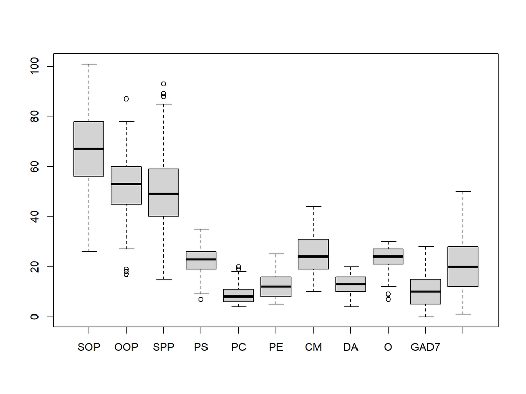

```r
bxplt <- boxplot(qu[, c("SOP", "OOP","SPP", "PS", "PC", "PE", "CM", "DA", "O","GAD7", "CESD")])
```

```r
# Standardize questionnaire variables
qu[, c("ZSOP", "ZOOP", "ZSPP", "ZPS", "ZPC", "ZPE", "ZCM", "ZDA", "ZO", "ZGAD7", "ZCESD")] <-
  scale(qu[, c("SOP", "OOP", "SPP", "PS", "PC", "PE", "CM", "DA", "O", "GAD7", "CESD")])

# Identify univariate outliers
univar_out <- c(
  which(qu$ZSOP > 3 | qu$ZSOP < -3),
  which(qu$ZOOP > 3 | qu$ZOOP < -3),
  which(qu$ZSPP > 3 | qu$ZSPP < -3),
  which(qu$ZPS > 3 | qu$ZPS < -3),
  which(qu$ZPE > 3 | qu$ZPE < -3),
  which(qu$ZPC > 3 | qu$ZPC < -3),
  which(qu$ZCM > 3 | qu$ZCM < -3),
  which(qu$ZDA > 3 | qu$ZDA < -3),
  which(qu$ZO > 3 | qu$ZO < -3),
  which(qu$ZGAD7 > 3 | qu$ZGAD7 < -3),
  which(qu$ZCESD > 3 | qu$ZCESD < -3)
)

univar_out <- unique(univar_out)
length(univar_out)
```

```
## [1] 6
```

```r
# Remove univariate outliers
qu <- qu[-univar_out, ]

# Identify multivariate outliers
vars <- qu[, c("SOP", "OOP", "SPP", "PS", "PC", "PE", "CM", "DA", "O", "GAD7", "CESD")]
md <- mahalanobis(vars, center = colMeans(vars), cov = cov(vars))
cutoff <- qchisq(p = 1 - .001, df = ncol(vars))
multivar_out_MH <- which(md > cutoff)

length(multivar_out_MH)
```

```
## [1] 0
```

Univariate outliers were excluded from subsequent analyses. No multivariate outliers were identified.

### Perfectionism Dimensions

Following Steober and Otto (2006), Perfectionistic Strivings was computed as the sum of standardized Personal Standards (FMPS-PS) and Self-Oriented Perfectionism (HMPS-SOP) scores. Perfectionistic Concerns was computed as the sum of standardized Concerns over Mistakes (FMPS-CM), Doubts about Actions (FMPS-DA), and Socially Prescribed Perfectionism (HMPS-SPP) scores.

```r
qu$Perf_Strivings <- rowSums(qu[, c("ZPS", "ZSOP")])
qu$Perf_Concerns  <- rowSums(qu[, c("ZCM", "ZDA", "ZSPP")])
```

## Attention Bias Assessment

### Response Time

Response times were defined as the latency between onset of the changed display and the participant’s response. Trial presentation order was retained as `trial_nr`. The ordering of the RT rows was verified against `TRIAL_INDEX` in the raw eye-tracking records.

Analyses were conducted on correct trials only, and trials with response times below 200 ms were excluded.

```r
rt$correct_response <- as.factor(rt$correct_response) %>%
  dplyr::recode("Vrai" = 1, "Faux" = 0)

incorrect <- which(rt$correct_response == 0)
rt200 <- which(rt$response_time < 200)

length(incorrect)
```

```
## [1] 241
```

```r
length(rt200)
```

```
## [1] 19
```

```r
rt <- rt[-c(incorrect, rt200), ]
```

Rule awareness was assessed at the end of each block and coded as a binary variable (0 = no, 1 = yes). This variable was retained as a control in subsequent models.

```r
rt <- rt %>% rename(guessed_block_rule = response_keyboard_response)
rt$guessed_block_rule <- as.factor(rt$guessed_block_rule) %>%
  dplyr::recode("o" = 1, "O" = 1, "n" = 0, "N" = 0)
```

### Eye Tracking

Eye movements during the 5000 ms free-viewing phase were used to compute the attentional indices. Raw eye-tracking data from Study 1 and the baseline session of Study 2 were merged prior to processing.

**Internal timing note.** The exported EyeLink variables are indexed according to the raw trial clock and labelled `IA_DWELL_TIME_500to1500`, `IA_DWELL_TIME_1500to3500`, and `IA_DWELL_TIME_3500to5500`. The word display began 500 ms after the start of that clock. Subtracting this 500-ms offset yields the stimulus-relative intervals reported in the analyses: 0–1000, 1000–3000, and 3000–5000 ms. This distinction should be retained in the analysis documentation so that the exported variable names are not mistaken for post-stimulus intervals.

Values outside the observable time window were treated as missing prior to index construction.

```r
out_first_fix_latency <- which(et$IA_FIRST_FIXATION_TIME > 5000)
length(out_first_fix_latency)
```

```
## [1] 780
```

```r
et$IA_FIRST_FIXATION_TIME[out_first_fix_latency] <- NA
```

```r
 #check missing values
length(which(is.na(et$IA_FIRST_FIXATION_VISITED_IA_COUNT))) #3090
length(which(is.na(et$IA_FIRST_FIXATION_TIME))) #3571
length(which(is.na(et$IA_DWELL_TIME))) #0
length(which(is.na(et$IA_DWELL_TIME_500to1500))) #0
length(which(is.na(et$IA_DWELL_TIME_1500to3500))) #0
length(which(is.na(et$IA_DWELL_TIME_3500to5500))) #0

#identify participants missing > 25% of trials => NONE
et$missing_IA_FIRST_FIXATION_VISITED_IA_COUNT <- NA
et$missing_IA_FIRST_FIXATION_TIME <- NA
for (participant in levels(as.factor(et$subject_id))){
  et$missing_IA_FIRST_FIXATION_VISITED_IA_COUNT[et$subject_id == participant] <- (length(which(is.na(et$IA_FIRST_FIXATION_VISITED_IA_COUNT[et$subject_id == participant])))/375)*100
  et$missing_IA_FIRST_FIXATION_TIME[et$subject_id == participant] <- (length(which(is.na(et$IA_FIRST_FIXATION_TIME[et$subject_id == participant])))/375)*100
}
describe(et[c("missing_IA_FIRST_FIXATION_VISITED_IA_COUNT", "missing_IA_FIRST_FIXATION_TIME")])
#                                            vars     n mean   sd median trimmed  mad min   max range skew kurtosis   se
# missing_IA_FIRST_FIXATION_VISITED_IA_COUNT    1 76111 4.03 4.19   2.67    3.39 3.56   0 21.87 21.87 1.56     3.03 0.02
# missing_IA_FIRST_FIXATION_TIME                2 76111 4.66 6.70   2.93    3.49 3.95   0 58.67 58.67 4.47    28.15 0.02

unique(et$subject_id[which(et$missing_IA_FIRST_FIXATION_TIME > 25)]) #16 17 18
et$missing_IA_FIRST_FIXATION_TIME[et$subject_id == '16'][1] #47.47
et$missing_IA_FIRST_FIXATION_TIME[et$subject_id == '17'][1] #58.67
et$missing_IA_FIRST_FIXATION_TIME[et$subject_id == '18'][1] #32.27
```

#### Attentional Indices

Attentional indices were derived to capture attentional engagement and maintenance and were expressed as proportions relative to competing stimuli. Following Skinner et al. (2018), these indices were aggregated at the block level, yielding one observation per semantic category per block (50 observations per participant).

The following indices were computed:

$$\textrm{Probability of first or second
fixation}= \frac {\textrm{Number of times the first or the second
fixation was to the target AOI}}{\textrm{ Total number of trials with a
first fixation × 2}}$$

$$\textrm{Latency to first fixation} =
\frac{\textrm{Mean latency of first fixation to target
AOI}}{\textrm{Mean latency of first fixation to target AOI} +
\textrm{Mean latency of first fixation to other AOIs}}$$

$$\textrm{Dwell time} = \frac{\textrm{Mean
dwell time in target AOI}}{\textrm{Mean dwell time in target AOI} +
\textrm{Mean dwell time in other AOIs}}$$
The viewing period was divided into three temporal phases:

- Early: 0–1000 ms
- Intermediate: 1000–3000 ms
- Late: 3000–5000 ms

Dwell time was computed for the early, intermediate, and late phases, as well as across the whole trial.

```r
# Merge ET with RT to recover block-level rule variables. Trial number comes
# from the eye-tracking export and provides the within-participant trial key.
rt_block_lookup <- rt %>%
  select(subject_id, trial_nr, Change_category, block_id, block_nr,
         guessed_block_rule) %>%
  distinct()

etrt <- et %>%
  rename(trial_nr = TRIAL_INDEX) %>%
  left_join(rt_block_lookup,
            by = c("subject_id", "trial_nr", "Change_category"),
            relationship = "many-to-one")

et_a <- etrt[c("subject_id", "block_id", "block_nr", "IA_LABEL", "Change_category", "guessed_block_rule",
               "IA_DWELL_TIME", "IA_DWELL_TIME_500to1500", "IA_DWELL_TIME_1500to3500", "IA_DWELL_TIME_3500to5500",
               "IA_FIRST_FIXATION_VISITED_IA_COUNT", "IA_FIRST_FIXATION_TIME")] %>%
  group_by(subject_id, block_id, block_nr, IA_LABEL, Change_category, guessed_block_rule) %>%
  reframe(
    IA_FIRST_FIXATION_PROBABILITY = mean(na.omit(IA_FIRST_FIXATION_VISITED_IA_COUNT)),
    IA_FIRST_FIXATION_TIME_BLOCKMEAN = mean(na.omit(IA_FIRST_FIXATION_TIME)),
    IA_DWELL_TIME_BLOCKMEAN = mean(IA_DWELL_TIME),
    IA_DWELL_TIME_500to1500_BLOCKMEAN = mean(IA_DWELL_TIME_500to1500),
    IA_DWELL_TIME_1500to3500_BLOCKMEAN = mean(IA_DWELL_TIME_1500to3500),
    IA_DWELL_TIME_3500to5500_BLOCKMEAN = mean(IA_DWELL_TIME_3500to5500)
  )

et_b <- et_a %>%
  group_by(subject_id, block_id, block_nr) %>%
  summarise(
    AVG_FIRST_FIXATION_TIME = sum(na.omit(IA_FIRST_FIXATION_TIME_BLOCKMEAN)),
    AVG_DWELL_TIME = sum(na.omit(IA_DWELL_TIME_BLOCKMEAN)),
    AVG_DWELL_TIME_500to1500 = sum(IA_DWELL_TIME_500to1500_BLOCKMEAN),
    AVG_DWELL_TIME_1500to3500 = sum(IA_DWELL_TIME_1500to3500_BLOCKMEAN),
    AVG_DWELL_TIME_3500to5500 = sum(IA_DWELL_TIME_3500to5500_BLOCKMEAN)
  )

et <- et_a %>% inner_join(et_b, relationship = "many-to-many")

et$first_fix_prob <- et$IA_FIRST_FIXATION_PROBABILITY
et$first_fix_latency <- et$IA_FIRST_FIXATION_TIME_BLOCKMEAN / et$AVG_FIRST_FIXATION_TIME
et$dwell_time <- et$IA_DWELL_TIME_BLOCKMEAN / et$AVG_DWELL_TIME
et$dwell_time_early <- et$IA_DWELL_TIME_500to1500_BLOCKMEAN / et$AVG_DWELL_TIME_500to1500
et$dwell_time_intermediate <- et$IA_DWELL_TIME_1500to3500_BLOCKMEAN / et$AVG_DWELL_TIME_1500to3500
et$dwell_time_late <- et$IA_DWELL_TIME_3500to5500_BLOCKMEAN / et$AVG_DWELL_TIME_3500to5500

# Remove remaining missing values
missing_ffp <- which(is.na(et$first_fix_prob))
missing_ffl <- which(is.na(et$first_fix_latency))
et <- et[-unique(c(missing_ffp, missing_ffl)), ]
```

## Descriptive Statistics

All questionnaire descriptives, reliability estimates, correlations, and participant-level symptom analyses were restricted to participants with usable attention-measurement data. The task dataset contains repeated observations, so the questionnaire dataset was filtered by participant identifier and retained one row per participant.

**Sample Demographics**

```r
task_completer_ids <- et %>%
  filter(!is.na(subject_id)) %>%
  distinct(subject_id)

qu_task <- qu %>%
  semi_join(task_completer_ids, by = "subject_id") %>%
  distinct(subject_id, .keep_all = TRUE)

stopifnot(nrow(qu_task) == n_distinct(qu_task$subject_id))
message("Study 1 task-completer questionnaire sample: N = ", nrow(qu_task))
```

```r
s1_desc_n <- nrow(qu_task)
s1_desc_fmt <- function(x, digits = 2L) {
  ifelse(is.finite(x), formatC(x, format = "f", digits = digits), "--")
}
s1_desc_categories <- function(x, heading, mapping) {
  x <- trimws(as.character(x))
  x[is.na(x) | x == ""] <- "Missing"
  matched <- match(x, names(mapping))
  x[!is.na(matched)] <- unname(mapping[matched[!is.na(matched)]])
  # Preserve any unexpected observed categories rather than silently dropping them.
  order <- unique(c(unname(mapping), sort(setdiff(x, c(unname(mapping), "Missing"))), "Missing"))
  counts <- table(factor(x, levels = order))
  counts <- counts[counts > 0L]
  data.frame(Characteristic = c(heading, paste0("  ", names(counts))),
             Value = c("", sprintf("%d (%.1f%%)", as.integer(counts),
                                    100 * as.integer(counts) / s1_desc_n)),
             check.names = FALSE)
}
s1_desc_age <- psych::describe(qu_task$Age)
s1_table11 <- rbind(
  data.frame(Characteristic = "Age, M (SD)",
             Value = paste0(s1_desc_fmt(s1_desc_age$mean), " (",
                            s1_desc_fmt(s1_desc_age$sd), ")")),
  s1_desc_categories(qu_task$Sexe, "Sex assigned at birth",
                     c("Femme" = "Female", "Homme" = "Male")),
  s1_desc_categories(qu_task$Actual_Studies, "Education level",
    c("Secondaires" = "Secondary", "BAC I" = "Bachelor 1", "BAC II" = "Bachelor 2",
      "BAC III" = "Bachelor 3", "BAC IV" = "Bachelor 4", "Master I" = "Master 1",
      "Master II" = "Master 2", "Master 60 complémentaire" = "Complementary 60-credit master's",
      "Doctorat" = "Doctorate")),
  s1_desc_categories(qu_task$Mother_Tongue, "Native language", c("Français" = "French"))
)
knitr::kable(s1_table11, row.names = FALSE, align = c("l", "r"),
  caption = paste0("Table 1.1. Demographic Characteristics of the Study 1 Sample (N = ", s1_desc_n, ")."))
```

Table 1.1. Demographic Characteristics of the Study 1 Sample (N = 202).

| Characteristic | Value |
| --- | --- |
| Age, M (SD) | 23.07 (5.96) |
| Sex assigned at birth |  |
| Female | 161 (79.7%) |
| Male | 41 (20.3%) |
| Education level |  |
| Secondary | 1 (0.5%) |
| Bachelor 1 | 31 (15.3%) |
| Bachelor 2 | 30 (14.9%) |
| Bachelor 3 | 34 (16.8%) |
| Bachelor 4 | 2 (1.0%) |
| Master 1 | 32 (15.8%) |
| Master 2 | 32 (15.8%) |
| Complementary 60-credit master’s | 1 (0.5%) |
| Doctorate | 2 (1.0%) |
| Missing | 37 (18.3%) |
| Native language |  |
| French | 199 (98.5%) |
| Missing | 3 (1.5%) |

*Note.* Percentages use the full analytic sample (N = 202); missing responses are reported where present. Age uses available observations (n = 202).

**Questionnaires**

Table 1.2 reports self-report descriptives calculated from the final analytic sample. Reliability calculations are retained below.

```r
alphaSOP <- psych::alpha(qu_task[, c("HMPS_1", "HMPS_6", "HMPS_8", "HMPS_12", "HMPS_14", "HMPS_15", "HMPS_17",
                                    "HMPS_20", "HMPS_23", "HMPS_28", "HMPS_32", "HMPS_34", "HMPS_36", "HMPS_40", "HMPS_42")])
alphaOOP <- psych::alpha(qu_task[, c("HMPS_2", "HMPS_3", "HMPS_4", "HMPS_7", "HMPS_10", "HMPS_16", "HMPS_19",
                                    "HMPS_22", "HMPS_24", "HMPS_26", "HMPS_27", "HMPS_29", "HMPS_38", "HMPS_43", "HMPS_45")])
alphaSPP <- psych::alpha(qu_task[, c("HMPS_5", "HMPS_9", "HMPS_11", "HMPS_13", "HMPS_18", "HMPS_21", "HMPS_25",
                                    "HMPS_30", "HMPS_31", "HMPS_33", "HMPS_35", "HMPS_37", "HMPS_39", "HMPS_41", "HMPS_44")])
alphaPS <- psych::alpha(qu_task[, c("FMPS_4", "FMPS_6", "FMPS_12", "FMPS_16", "FMPS_19", "FMPS_24", "FMPS_30")])
alphaPE <- psych::alpha(qu_task[, c("FMPS_1", "FMPS_11", "FMPS_15", "FMPS_20", "FMPS_26")])
alphaPC <- psych::alpha(qu_task[, c("FMPS_3", "FMPS_5", "FMPS_22", "FMPS_35")])
alphaCM <- psych::alpha(qu_task[, c("FMPS_9", "FMPS_10", "FMPS_13", "FMPS_14", "FMPS_18", "FMPS_21", "FMPS_23", "FMPS_25", "FMPS_34")])
alphaDA <- psych::alpha(qu_task[, c("FMPS_17", "FMPS_28", "FMPS_32", "FMPS_33")])
alphaO <- psych::alpha(qu_task[, c("FMPS_2", "FMPS_7", "FMPS_8", "FMPS_27", "FMPS_29", "FMPS_31")])
alphaPerf_Strivings <- psych::alpha(qu_task[, c("ZPS", "ZSOP")])
alphaPerf_Concerns <- psych::alpha(qu_task[, c("ZCM", "ZDA", "ZSPP")])
alphaGAD7 <- psych::alpha(qu_task[, paste0("GAD7_", 1:7)])
alphaCESD <- psych::alpha(qu_task[, paste0("CESD_", 1:20)])

# Print reliability estimates for the final participant-level analytic sample.
alpha_results <- list(
  "HMPS SOP" = alphaSOP, "HMPS OOP" = alphaOOP, "HMPS SPP" = alphaSPP,
  "FMPS PS" = alphaPS, "FMPS PE" = alphaPE, "FMPS PC" = alphaPC,
  "FMPS CM" = alphaCM, "FMPS DA" = alphaDA, "FMPS O" = alphaO,
  "CES-D" = alphaCESD, "GAD-7" = alphaGAD7,
  "Strivings (subscale scores)" = alphaPerf_Strivings,
  "Concerns (subscale scores)" = alphaPerf_Concerns
)
alpha_table <- do.call(rbind, lapply(names(alpha_results), function(scale_name) {
  result <- alpha_results[[scale_name]]
  data.frame(
    Scale = scale_name,
    Sample_N = nrow(qu_task),
    Items_or_subscales = nrow(result$item.stats),
    Minimum_item_N = min(result$item.stats$n),
    Maximum_item_N = max(result$item.stats$n),
    Raw_alpha = result$total$raw_alpha,
    Standardized_alpha = result$total$std.alpha,
    check.names = FALSE
  )
}))
cat("\nCronbach's alpha: final analytic sample (Study 1)\n")
```

```
##
## Cronbach's alpha: final analytic sample (Study 1)
```

```r
print(alpha_table, row.names = FALSE, digits = 6)
```

```
##                        Scale Sample_N Items_or_subscales Minimum_item_N
##                     HMPS SOP      202                 15            202
##                     HMPS OOP      202                 15            202
##                     HMPS SPP      202                 15            202
##                      FMPS PS      202                  7            202
##                      FMPS PE      202                  5            202
##                      FMPS PC      202                  4            202
##                      FMPS CM      202                  9            202
##                      FMPS DA      202                  4            202
##                       FMPS O      202                  6            202
##                        CES-D      202                 20            202
##                        GAD-7      202                  7            202
##  Strivings (subscale scores)      202                  2            202
##   Concerns (subscale scores)      202                  3            202
##  Maximum_item_N Raw_alpha Standardized_alpha
##             202  0.910760           0.908332
##             202  0.791484           0.795985
##             202  0.880763           0.884389
##             202  0.779672           0.782351
##             202  0.864216           0.865007
##             202  0.798414           0.797738
##             202  0.875242           0.872922
##             202  0.714739           0.717549
##             202  0.890411           0.894698
##             202  0.906807           0.904871
##             202  0.908989           0.906946
##             202  0.850213           0.850268
##             202  0.718340           0.718352
```

```r
s1_desc_vars <- c("SOP", "OOP", "SPP", "PS", "PE", "PC", "CM", "DA", "O",
                   "Perf_Strivings", "Perf_Concerns", "GAD7", "CESD")
s1_desc_labels <- c("Self-Oriented Perfectionism (SOP)", "Other-Oriented Perfectionism (OOP)",
  "Socially Prescribed Perfectionism (SPP)", "Personal Standards (PS)",
  "Parental Expectations (PE)", "Parental Criticism (PC)", "Concern Over Mistakes (CM)",
  "Doubts About Actions (DA)", "Organization (O)", "Perfectionistic Strivings",
  "Perfectionistic Concerns", "Anxiety (GAD-7)", "Depression (CES-D)")
s1_desc_qu <- psych::describe(qu_task[s1_desc_vars])
s1_table12 <- data.frame(Measure = s1_desc_labels,
  M = s1_desc_qu$mean, SD = s1_desc_qu$sd, Skew = s1_desc_qu$skew,
  Kurtosis = s1_desc_qu$kurtosis, Min = s1_desc_qu$min, Max = s1_desc_qu$max,
  check.names = FALSE)
knitr::kable(s1_table12, digits = 2, row.names = FALSE,
  caption = "Table 1.2. Descriptive Statistics for Self-Report Measures.")
```

Table 1.2. Descriptive Statistics for Self-Report Measures.

| Measure | M | SD | Skew | Kurtosis | Min | Max |
| --- | --- | --- | --- | --- | --- | --- |
| Self-Oriented Perfectionism (SOP) | 67.07 | 15.67 | -0.07 | -0.56 | 26.00 | 101.00 |
| Other-Oriented Perfectionism (OOP) | 52.80 | 10.56 | -0.16 | -0.03 | 19.00 | 78.00 |
| Socially Prescribed Perfectionism (SPP) | 49.99 | 13.59 | 0.29 | -0.09 | 15.00 | 89.00 |
| Personal Standards (PS) | 22.50 | 5.31 | -0.25 | -0.50 | 9.00 | 34.00 |
| Parental Expectations (PE) | 12.58 | 5.00 | 0.46 | -0.72 | 5.00 | 25.00 |
| Parental Criticism (PC) | 8.68 | 3.73 | 0.86 | 0.05 | 4.00 | 20.00 |
| Concern Over Mistakes (CM) | 24.87 | 8.09 | 0.18 | -0.90 | 10.00 | 43.00 |
| Doubts About Actions (DA) | 13.21 | 3.51 | -0.02 | -0.77 | 4.00 | 20.00 |
| Organization (O) | 23.36 | 4.79 | -0.67 | 0.03 | 9.00 | 30.00 |
| Perfectionistic Strivings | -0.01 | 1.81 | -0.16 | -0.53 | -4.47 | 4.07 |
| Perfectionistic Concerns | -0.05 | 2.36 | 0.17 | -0.41 | -6.09 | 6.59 |
| Anxiety (GAD-7) | 10.15 | 6.20 | 0.26 | -0.67 | 0.00 | 28.00 |
| Depression (CES-D) | 19.96 | 10.37 | 0.33 | -0.80 | 1.00 | 44.00 |

*Note.* N = 202 for all measures. Skewness and kurtosis retain the existing `psych::describe` defaults.

**Correlations**

Table 1.3 displays correlations among the two perfectionism dimensions and anxiety/depressive symptoms. The original full correlation calculation is retained; only these four variables are displayed in the lower triangle.

```r
corr_table <- corr.test(qu_task[c("SOP", "OOP", "SPP", "PS", "PE", "PC", "CM", "DA", "O",
                                  "Perf_Strivings", "Perf_Concerns", "GAD7", "CESD")])$stars
s1_corr_vars <- c("Perf_Strivings", "Perf_Concerns", "GAD7", "CESD")
s1_corr_display <- corr_table[s1_corr_vars, s1_corr_vars, drop = FALSE]
s1_corr_display[upper.tri(s1_corr_display)] <- ""
diag(s1_corr_display) <- "—"
s1_table13 <- data.frame(Variable = c("1. Perfectionistic Strivings", "2. Perfectionistic Concerns",
                                      "3. Anxiety (GAD-7)", "4. Depression (CES-D)"),
                          s1_corr_display, check.names = FALSE)
names(s1_table13) <- c("Variable", "1", "2", "3", "4")
knitr::kable(s1_table13, row.names = FALSE,
  caption = "Table 1.3. Correlations Among Perfectionism Dimensions and Psychological Distress Measures.")
```

Table 1.3. Correlations Among Perfectionism Dimensions and Psychological Distress Measures.

| Variable | 1 | 2 | 3 | 4 |
| --- | --- | --- | --- | --- |
| 1. Perfectionistic Strivings | — |  |  |  |
| 2. Perfectionistic Concerns | 0.61*** | — |  |  |
| 3. Anxiety (GAD-7) | 0.25*** | 0.43*** | — |  |
| 4. Depression (CES-D) | 0.29*** | 0.53*** | 0.71*** | — |

*Note.* Analytic sample N = 202; correlations use available pairs. Significance markers are retained from the original lower triangle of `psych::corr.test`: *p* < .05 (one star), *p* < .01 (two stars), and *p* < .001 (three stars).

**Attentional Measures**

Table 1.4 summarizes the existing block-level eye-tracking observations and correct trial-level response times from the analytic sample.

```r
# Preserve the existing observation-level summaries; N refers to participants.
s1_desc_et_vars <- c("first_fix_prob", "first_fix_latency", "dwell_time",
                     "dwell_time_early", "dwell_time_intermediate", "dwell_time_late")
s1_desc_et <- psych::describe(et_qu[s1_desc_et_vars])
s1_desc_rt <- psych::describe(rt_qu$response_time)
s1_desc_attention <- rbind(as.data.frame(s1_desc_et)[, c("mean", "sd", "min", "max")],
                           as.data.frame(s1_desc_rt)[, c("mean", "sd", "min", "max")])
s1_table14 <- data.frame(Measure = c("Probability of First or Second Fixation",
  "Latency to First Fixation", "Total Dwell Time", "Early Dwell Time",
  "Intermediate Dwell Time", "Late Dwell Time", "Response Time (ms)"),
  N = s1_desc_n, M = s1_desc_attention$mean, SD = s1_desc_attention$sd,
  Min = s1_desc_attention$min, Max = s1_desc_attention$max, check.names = FALSE)
knitr::kable(s1_table14, digits = c(0, 0, 2, 2, 2, 2), row.names = FALSE,
  caption = "Table 1.4. Descriptive Statistics for Attentional Measures.")
```

Table 1.4. Descriptive Statistics for Attentional Measures.

| Measure | N | M | SD | Min | Max |
| --- | --- | --- | --- | --- | --- |
| Probability of First or Second Fixation | 202 | 0.42 | 0.21 | 0.00 | 1.00 |
| Latency to First Fixation | 202 | 0.19 | 0.04 | 0.02 | 0.59 |
| Total Dwell Time | 202 | 0.19 | 0.11 | 0.01 | 0.97 |
| Early Dwell Time | 202 | 0.19 | 0.10 | 0.00 | 1.00 |
| Intermediate Dwell Time | 202 | 0.19 | 0.08 | 0.00 | 0.98 |
| Late Dwell Time | 202 | 0.19 | 0.14 | 0.00 | 1.00 |
| Response Time (ms) | 202 | 1704.15 | 1028.05 | 212.00 | 11124.00 |

*Note.* N denotes the common analytic sample of participants. Eye-tracking means and standard deviations summarize block-level observations, and response-time descriptives summarize correct trial-level observations contributed by these participants. Eye-tracking indices are probabilities or proportions (including proportional latency); response times are milliseconds. Scores are summarized before model boundary adjustment.

## Distributional Inspection

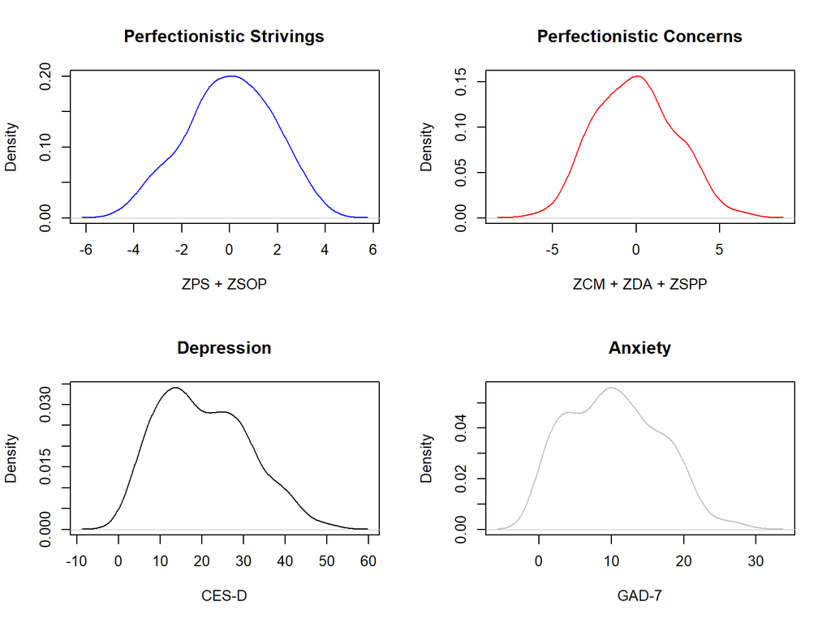

```r
par(mfrow = c(2, 2))

plot(density(as.numeric(na.omit(qu_task$Perf_Strivings))),
     col = "blue",
     main = "Perfectionistic Strivings",
     xlab = "ZPS + ZSOP")

plot(density(as.numeric(na.omit(qu_task$Perf_Concerns))),
     col = "red",
     main = "Perfectionistic Concerns",
     xlab = "ZCM + ZDA + ZSPP")

plot(density(as.numeric(na.omit(qu$CESD))),
     col = "black",
     main = "Depression",
     xlab = "CES-D")

plot(density(as.numeric(na.omit(qu$GAD7))),
     col = "grey",
     main = "Anxiety",
     xlab = "GAD-7")
```

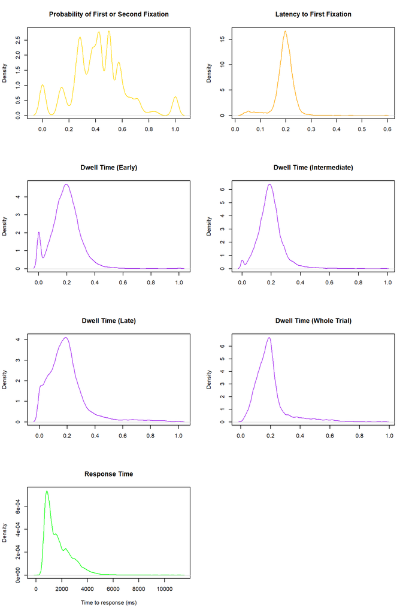

```r
par(mfrow = c(4, 2))

plot(density(as.numeric(na.omit(et$first_fix_prob))),
     col = "gold",
     main = "Probability of First or Second Fixation",
     xlab = "")

plot(density(as.numeric(na.omit(et$first_fix_latency))),
     col = "orange",
     main = "Latency to First Fixation",
     xlab = "")

plot(density(as.numeric(na.omit(et$dwell_time_early))),
     col = "purple",
     main = "Dwell Time (Early)",
     xlab = "")

plot(density(as.numeric(na.omit(et$dwell_time_intermediate))),
     col = "purple",
     main = "Dwell Time (Intermediate)",
     xlab = "")

plot(density(as.numeric(na.omit(et$dwell_time_late))),
     col = "purple",
     main = "Dwell Time (Late)",
     xlab = "")

plot(density(as.numeric(na.omit(et$dwell_time))),
     col = "purple",
     main = "Dwell Time (Whole Trial)",
     xlab = "")

plot(density(as.numeric(na.omit(rt$response_time))),
     col = "green",
     main = "Response Time",
     xlab = "Time to response (ms)")
```

_________________________________________________________________

# Associations Between Perfectionism and Attention

These analyses estimated associations between perfectionism and attentional outcomes, including the proportion of first or second fixation, proportional latency to first fixation, proportional dwell time, and response time.

The outcomes were analyzed using **generalized linear mixed-effects models (GLMMs)** fitted with `glmmTMB` (Brooks et al., 2017). This framework accommodates the heterogeneous distributional properties of the attentional outcomes while representing dependence associated with participants and block positions. Proportional eye-tracking outcomes were fitted with beta mixed models and a logit link; positively skewed response times were fitted with gamma mixed models and a log link. Rule awareness was included in the dispersion submodel because variability in performance could differ after participants inferred the block rule.

The multilevel structure distinguished variation

- **between participants**, represented by a participant random intercept,
- **between participants in the target-AOI effect**, represented where supported by an uncorrelated participant-specific random slope for `Change_category01`,
- **across presentation order**, represented by a fixed time effect estimating the average linear trend, and
- **within participant-by-block observations**, represented by the conditional residual variation.

For eye-tracking outcomes, centered numeric block presentation order was included as a fixed effect estimating the average linear time trend. `Change_category01` indicated whether an AOI belonged to the semantic category targeted by the current block rule and was included as both a fixed effect and an uncorrelated participant-specific random slope. Response-time models retained numeric trial presentation order as a fixed covariate and a participant random intercept.

Note. A block-identity random intercept was considered but omitted because it caused estimation problems for several outcomes and explained negligible variance where estimable

### i) Model Inputs and Predictor Coding

#### Semantic Coding

Semantic category was represented as a five-level factor comprising neutral, positive, negative, success-related, and failure-related stimuli, with Neutral specified as the reference category. For response-time models, semantic category referred to the changed word; for eye-tracking models, it referred to the AOI category.

Because Neutral was the reference category, the interaction coefficients in the factor-coded GLMM tested whether the perfectionism slope for each other semantic category differed from the slope for Neutral; they did not test whether a category-specific slope differed from zero. Following a supported omnibus interaction, `emtrends()` was therefore used to estimate and test the perfectionism slope separately within each of the five semantic categories.

Because the attentional outcomes were proportions, these slopes indicated whether the share of attention allocated to a category changed as a function of perfectionism. Such a change necessarily reflected redistribution across the categories in the display, although a category-specific slope did not identify the categories against which that redistribution occurred.

Four planned comparisons among the slopes directly tested whether associations with perfectionism differed according to positive versus negative, success versus failure, performance-irrelevant versus performance-relevant, and neutral versus non-neutral content. More specifically, `emtrends()` first recovered the estimated perfectionism slope, denoted below by $s$, within each semantic category. `contrast()` then formed the following weighted combinations of those slopes:

- positive versus negative: $(s_{Negative}+s_{Failure})-(s_{Positive}+s_{Success})$;
- success versus failure: $s_{Failure}-s_{Success}$;
- performance-irrelevant versus performance-relevant: $3(s_{Success}+s_{Failure})- 2(s_{Neutral}+s_{Positive}+s_{Negative})$; and
- neutral versus non-neutral content: $(s_{Positive}+s_{Negative}+ s_{Success}+s_{Failure})-4s_{Neutral}$.

The integer weights below are scaled versions of differences between the corresponding category averages. For example, the performance-irrelevant versus performance-relevant contrast is six times the difference between the mean slope for the two performance-relevant categories and the mean slope for the three performance-irrelevant categories. Multiplying every weight in a contrast by the same positive constant changes the scale of its estimate and standard error, but not its test statistic or *p* value.

Thus, the planned tests assess whether the perfectionism slopes differ across the theoretically defined sets of categories; the separate `emtrends()` tests assess whether the slope within each individual category differs from zero.

```r
semantic_levels <- c("Neutral", "Positive", "Negative", "Success", "Failure")

rt_qu$Change_category_f <- factor(
  rt_qu$Change_category,
  levels = semantic_levels
)
stopifnot(levels(rt_qu$Change_category_f)[1] == "Neutral")

# Planned comparisons among factor levels for emmeans follow-ups. Each vector
# is explicitly named to show the category mapping and uses the agreed integer
# coding. The comments below identify the comparison names.
semantic_planned <- list(
  # Positive versus negative, irrespective of performance relevance
  positive_vs_negative = c(
    Neutral = 0, Positive = -1, Negative = 1, Success = -1, Failure = 1
  ),
  # Success versus failure
  success_vs_failure = c(
    Neutral = 0, Positive = 0, Negative = 0, Success = -1, Failure = 1
  ),
  # Performance-irrelevant versus performance-relevant
  performance_irrelevant_vs_relevant = c(
    Neutral = -2, Positive = -2, Negative = -2, Success = 3, Failure = 3
  ),
  # Neutral versus non-neutral
  neutral_vs_nonneutral = c(
    Neutral = -4, Positive = 1, Negative = 1, Success = 1, Failure = 1
  )
)

stopifnot(
  all(vapply(semantic_planned, sum, numeric(1)) == 0),
  all(vapply(semantic_planned, function(x) identical(names(x), semantic_levels),
             logical(1)))
)

# Colorblind-accessible Okabe-Ito palette.
semantic_colors <- c(
  Neutral = "#000000", Positive = "#56B4E9", Negative = "#D55E00",
  Success = "#009E73", Failure = "#CC79A7"
)
contrast_colors <- c(
  positive_vs_negative = "#0072B2", success_vs_failure = "#D55E00",
  performance_irrelevant_vs_relevant = "#009E73",
  neutral_vs_nonneutral = "#CC79A7"
)
contrast_labels <- c(
  positive_vs_negative = "Positive vs. negative",
  success_vs_failure = "Success vs. failure",
  performance_irrelevant_vs_relevant = "Performance-irrelevant\nvs. performance-relevant",
  neutral_vs_nonneutral = "Neutral vs. non-neutral"
)

# Enlarged source typography remains legible after two plots are combined.
figure3_theme <- theme_minimal(base_size = 17) +
  theme(
    plot.title = element_text(size = 19, face = "bold"),
    axis.title = element_text(size = 16),
    axis.text = element_text(size = 14),
    legend.title = element_text(size = 15),
    legend.text = element_text(size = 14),
    legend.key.height = unit(18, "pt")
  )
```

```r
et_qu$IA_LABEL_f <- factor(
  et_qu$IA_LABEL,
  levels = semantic_levels
)
stopifnot(levels(et_qu$IA_LABEL_f)[1] == "Neutral")
```

#### Centering Predictors

Prior to analyses, Perfectionistic Strivings and Perfectionistic Concerns were mean-centered to make lower-order terms interpretable at the sample means.

```r
qu_task$Perf_Strivings_c <- qu_task$Perf_Strivings - mean(qu_task$Perf_Strivings, na.rm = TRUE)
qu_task$Perf_Concerns_c <- qu_task$Perf_Concerns - mean(qu_task$Perf_Concerns, na.rm = TRUE)

rt_qu$Perf_Strivings_c <- rt_qu$Perf_Strivings - mean(qu_task$Perf_Strivings, na.rm = TRUE)
rt_qu$Perf_Concerns_c <- rt_qu$Perf_Concerns - mean(qu_task$Perf_Concerns, na.rm = TRUE)

et_qu$Perf_Strivings_c <- et_qu$Perf_Strivings - mean(qu_task$Perf_Strivings, na.rm = TRUE)
et_qu$Perf_Concerns_c <- et_qu$Perf_Concerns - mean(qu_task$Perf_Concerns, na.rm = TRUE)
```

#### Participant and Block Structure

Repeated observations were modeled using participant-specific random effects. For eye-tracking outcomes, the model included a participant random intercept and an uncorrelated participant-specific random slope for `Change_category01`.

Centered block order was retained as a fixed effect to estimate the average linear time trend across participants. For trial-level response times, numeric trial presentation order was retained as a fixed covariate and participant was included as a random intercept. `Change_category01` additionally controlled whether an eye-tracking AOI matched the category targeted within that block.

```r
rt_qu$subject_id <- as.factor(rt_qu$subject_id)
rt_qu$block_id <- as.factor(rt_qu$block_id)
rt_qu$block_nr <- as.integer(rt_qu$block_nr)
rt_qu$trial_nr <- as.integer(rt_qu$trial_nr)
rt_qu$trial_nr_c <- rt_qu$trial_nr - mean(rt_qu$trial_nr, na.rm = TRUE)

et_qu$subject_id <- as.factor(et_qu$subject_id)
et_qu$block_id <- as.factor(et_qu$block_id)
et_qu$block_nr <- as.integer(et_qu$block_nr)
et_qu$block_nr_c <- et_qu$block_nr - mean(et_qu$block_nr, na.rm = TRUE)
```

For eye-tracking analyses, a binary indicator (Change_category01) was created to denote whether a given AOI matched the semantic category targeted by the change rule within a block (0 = non-target, 1 = target).

```r
et_qu$Change_category <- as.factor(et_qu$Change_category)
et_qu$Change_category01 <- 0
et_qu$Change_category01 <- as.integer(
  as.character(et_qu$IA_LABEL) == as.character(et_qu$Change_category)
)
```

#### Hierarchical Model-Building Strategy

For each attentional outcome, models were estimated hierarchically.

- The **null model** for eye-tracking outcomes included mean-centered block presentation order, the fixed target-AOI indicator, the outcome-specific participant random-effects structure, and rule awareness in the dispersion submodel. The response-time null model included mean-centered trial presentation order, a participant random intercept, and rule awareness in the dispersion submodel.
- The **partial model** added semantic category as a five-level factor comprising neutral, positive, negative, success-related, and failure-related stimuli.
- The **full models** separately added either mean-centered Perfectionistic Strivings or mean-centered Perfectionistic Concerns and their interaction with the five-level semantic-category factor.

Likelihood-ratio tests and AIC were used to determine whether adding semantic category improved fit relative to the null model and whether adding a perfectionism-by-semantic-category interaction improved fit relative to the partial model. Category-specific trends and planned theoretical comparisons were interpreted only when the corresponding full model improved fit.

#### Model Diagnostic Functions

Model fit was evaluated using Pearson residual-versus-fitted plots and simulation-based predictive checks comparing observed and model-implied outcome distributions. Convergence warnings and near-zero variance components were also be inspected for every fitted model.

## ii) Beta Regression for Eye-Tracking Indices

Probability of first or second fixation, latency to first fixation, and dwell time reflect the relative allocation of attention to a target AOI and were therefore modeled as continuous proportions bounded between 0 and 1.

These indices require a distribution that accommodates bounded, potentially asymmetric data. The **beta distribution** is well suited for this purpose (Douma & Weedon, 2019). In addition to modeling the expected value of the outcome ($\mu$), `glmmTMB` allows the beta precision parameter to vary as a function of predictors. Rule awareness was entered in this dispersion submodel to allow residual variability in attentional allocation to differ according to whether participants had inferred the block rule.

### Model Overview

- **Outcome:** Continuous proportions
- **Distribution:** Beta
- **Parameters:**
  - $\mu$: mean (expected proportion)
  - $\phi$: precision (larger values imply less conditional variance)

### Link Functions

A **logit** link was used for all proportional outcomes, yielding fixed-effect coefficients on the log-odds scale. Coefficients are reported on that scale. Substantive response-scale interpretation uses estimated marginal trends or predictions formed from the complete linear predictor and then transformed with the inverse-logit function; applying the inverse logit to a slope or interaction coefficient by itself does not yield a change in proportion (Douma & Weedon, 2019).

### Model Specification for Eye-Tracking Indices

All eye-tracking indices were modeled using **beta GLMMs** with a logit link for the conditional mean.

#### Mean Submodel ($\mu$)

$$\begin{aligned}
g(\mu_{ij}) ={}& \beta_0 + \sum_{k=1}^{4}\beta_k C_{k,ij} + \beta_5
Perf_j + \beta_6 BlockOrder_{ij} + \delta ChangeCategory_{ij} \\
&+ \sum_{k=1}^{4}\gamma_k(C_{k,ij}\times Perf_j) \\
&+ u_{0j} + u_{1j}ChangeCategory_{ij}.
\end{aligned}$$

where:

- $g(\cdot)$: logit link
- $\mu_{ij}$: expected value of the attentional index for block $i$ and participant $j$
- $C_{k,ij}$: four indicator variables for positive, negative, success-related, and failure-related stimuli; neutral is the reference category
- $Perf_j$: perfectionism (Perfectionistic Strivings or Perfectionistic Concerns, modeled in separate analyses; mean-centered)
- $BlockOrder_{ij}$: mean-centered numeric presentation order of the block (1–10)
- $u_{0j}$: participant-specific random intercept
- $u_{1j}$: participant-specific deviation from the average target-AOI effect (where supported)
- $ChangeCategory_{ij}$: whether the AOI matched the category targeted within its block

#### Dispersion Submodel ($\phi$)

$$\log(\phi_{ij}) = \delta_0 + \delta_1 BR_{ij}$$

where:

- $\phi_{ij}$: beta precision parameter
- $BR_{ij}$: rule awareness (0 = no, 1 = yes)

### Data Preparation for Beta Models

To reduce memory usage and computation time, a subset containing only variables required for model fitting was created.

```r
sub_et_qu <- et_qu[c("first_fix_prob", "first_fix_latency", "dwell_time",
                     "dwell_time_early", "dwell_time_intermediate", "dwell_time_late",
                     "subject_id", "block_id", "block_nr", "block_nr_c",
                     "guessed_block_rule", "Change_category01", "IA_LABEL_f",
                     "Perf_Strivings_c" , "Perf_Concerns_c")]
```

Because the beta distribution is defined on the open interval $(0, 1)$, observations equal to 0 or 1 were slightly adjusted prior to model fitting. These boundary values were treated as measurement-related rather than substantively distinct outcomes: given the simultaneous circular presentation of all stimulus categories, an observed proportion of zero generally indicated that no valid fixation was recorded for that category within the relevant measurement window, rather than the complete absence of attentional allocation.

```r
transform01 <- function(x) {
  n <- sum(!is.na(x))
  ifelse(is.na(x), NA_real_, (x * (n - 1) + 0.5) / n)
}

sub_et_qu$first_fix_prob_t01 <- transform01(sub_et_qu$first_fix_prob)
sub_et_qu$first_fix_latency_t01 <- transform01(sub_et_qu$first_fix_latency)
sub_et_qu$dwell_time_early_t01 <- transform01(sub_et_qu$dwell_time_early)
sub_et_qu$dwell_time_intermediate_t01 <- transform01(sub_et_qu$dwell_time_intermediate)
sub_et_qu$dwell_time_late_t01 <- transform01(sub_et_qu$dwell_time_late)
sub_et_qu$dwell_time_t01 <- transform01(sub_et_qu$dwell_time)
```

### 1. Probability of First or Second Fixation

Probability of first or second fixation was modeled using a **beta GLMM** with a logit link for the mean parameter.

##### bm0_first_fix_prob

**Null model**

```r
bm0_first_fix_prob <- glmmTMB(
  first_fix_prob_t01 ~
    block_nr_c +
    Change_category01 +
    #(1 | block_id) +
    (1 + Change_category01 || subject_id),
  family = beta_family(link = "logit"),
  dispformula = ~ guessed_block_rule,
  data = na.omit(sub_et_qu),

)
summary(bm0_first_fix_prob)
```

```
##  Family: beta  ( logit )
## Formula:
## first_fix_prob_t01 ~ block_nr_c + Change_category01 + (1 + Change_category01 ||
##     subject_id)
## Dispersion:                          ~guessed_block_rule
## Data: na.omit(sub_et_qu)
##
##      AIC      BIC   logLik deviance df.resid
##  -3667.0  -3616.5   1840.5  -3681.0    10089
##
## Random effects:
##
## Conditional model:
##  Groups     Name              Variance Std.Dev. Corr
##  subject_id (Intercept)       0.007629 0.08735
##             Change_category01 0.040738 0.20184  0.00
## Number of obs: 10096, groups:  subject_id, 202
##
## Conditional model:
##                    Estimate Std. Error z value Pr(>|z|)
## (Intercept)       -0.316790   0.011354 -27.902  < 2e-16 ***
## block_nr_c         0.007379   0.002968   2.486   0.0129 *
## Change_category01 -0.177156   0.025728  -6.886 5.75e-12 ***
## ---
## Signif. codes:  0 '***' 0.001 '**' 0.01 '*' 0.05 '.' 0.1 ' ' 1
##
## Dispersion model:
##                    Estimate Std. Error z value Pr(>|z|)
## (Intercept)         1.49751    0.03023   49.54   <2e-16 ***
## guessed_block_rule -0.01377    0.03333   -0.41     0.68
## ---
## Signif. codes:  0 '***' 0.001 '**' 0.01 '*' 0.05 '.' 0.1 ' ' 1
```

##### bm1_first_fix_prob

**Partial Model**

```r
bm1_first_fix_prob <- glmmTMB(
  first_fix_prob_t01 ~
    IA_LABEL_f +
    block_nr_c +
    Change_category01 +
    #(1 | block_id) +
    (1 + Change_category01 || subject_id),
  dispformula = ~ guessed_block_rule,
  family = beta_family(link = "logit"),
  data = na.omit(sub_et_qu),

)
summary(bm1_first_fix_prob)
```

```
##  Family: beta  ( logit )
## Formula:
## first_fix_prob_t01 ~ IA_LABEL_f + block_nr_c + Change_category01 +
##     (1 + Change_category01 || subject_id)
## Dispersion:                          ~guessed_block_rule
## Data: na.omit(sub_et_qu)
##
##      AIC      BIC   logLik deviance df.resid
##  -3696.1  -3616.6   1859.0  -3718.1    10085
##
## Random effects:
##
## Conditional model:
##  Groups     Name              Variance Std.Dev. Corr
##  subject_id (Intercept)       0.007519 0.08671
##             Change_category01 0.040691 0.20172  0.00
## Number of obs: 10096, groups:  subject_id, 202
##
## Conditional model:
##                     Estimate Std. Error z value Pr(>|z|)
## (Intercept)        -0.307703   0.020434 -15.058  < 2e-16 ***
## IA_LABEL_fPositive  0.071556   0.026887   2.661  0.00778 **
## IA_LABEL_fNegative -0.090603   0.026939  -3.363  0.00077 ***
## IA_LABEL_fSuccess  -0.004612   0.026921  -0.171  0.86397
## IA_LABEL_fFailure  -0.022074   0.026917  -0.820  0.41217
## block_nr_c          0.007322   0.002964   2.470  0.01351 *
## Change_category01  -0.177593   0.025708  -6.908 4.92e-12 ***
## ---
## Signif. codes:  0 '***' 0.001 '**' 0.01 '*' 0.05 '.' 0.1 ' ' 1
##
## Dispersion model:
##                    Estimate Std. Error z value Pr(>|z|)
## (Intercept)         1.50534    0.03028   49.71   <2e-16 ***
## guessed_block_rule -0.01890    0.03339   -0.57    0.571
## ---
## Signif. codes:  0 '***' 0.001 '**' 0.01 '*' 0.05 '.' 0.1 ' ' 1
```

**Comparison of model fit (bm1 vs. bm0)**

```r
lrtest(bm0_first_fix_prob, bm1_first_fix_prob)
```

```
## Likelihood ratio test
##
## Model 1: first_fix_prob_t01 ~ block_nr_c + Change_category01 + (1 + Change_category01 ||
##     subject_id)
## Model 2: first_fix_prob_t01 ~ IA_LABEL_f + block_nr_c + Change_category01 +
##     (1 + Change_category01 || subject_id)
##   #Df LogLik Df  Chisq Pr(>Chisq)
## 1   7 1840.5
## 2  11 1859.0  4 37.046  1.762e-07 ***
## ---
## Signif. codes:  0 '***' 0.001 '**' 0.01 '*' 0.05 '.' 0.1 ' ' 1
```

```r
AIC(bm1_first_fix_prob, bm0_first_fix_prob)
```

```
##                    df       AIC
## bm1_first_fix_prob 11 -3696.051
## bm0_first_fix_prob  7 -3667.005
```

##### bm2.1_first_fix_prob

**Full model: Perfectionistic Strivings**

```r
bm2.1_first_fix_prob <- glmmTMB(
  first_fix_prob_t01 ~
    IA_LABEL_f * Perf_Strivings_c +
    block_nr_c +
    Change_category01 +
    #(1 | block_id)
    (1 + Change_category01 || subject_id),
  dispformula = ~ guessed_block_rule,
  family = beta_family(link = "logit"),
  data = na.omit(sub_et_qu),

)
summary(bm2.1_first_fix_prob)
```

```
##  Family: beta  ( logit )
## Formula:
## first_fix_prob_t01 ~ IA_LABEL_f * Perf_Strivings_c + block_nr_c +
##     Change_category01 + (1 + Change_category01 || subject_id)
## Dispersion:                          ~guessed_block_rule
## Data: na.omit(sub_et_qu)
##
##      AIC      BIC   logLik deviance df.resid
##  -3698.1  -3582.6   1865.1  -3730.1    10080
##
## Random effects:
##
## Conditional model:
##  Groups     Name              Variance Std.Dev. Corr
##  subject_id (Intercept)       0.00694  0.08331
##             Change_category01 0.03979  0.19946  0.00
## Number of obs: 10096, groups:  subject_id, 202
##
## Conditional model:
##                                      Estimate Std. Error z value Pr(>|z|)
## (Intercept)                         -0.307780   0.020361 -15.116  < 2e-16 ***
## IA_LABEL_fPositive                   0.071591   0.026880   2.663 0.007736 **
## IA_LABEL_fNegative                  -0.090454   0.026938  -3.358 0.000786 ***
## IA_LABEL_fSuccess                   -0.004557   0.026915  -0.169 0.865563
## IA_LABEL_fFailure                   -0.022064   0.026912  -0.820 0.412311
## Perf_Strivings_c                    -0.022640   0.011115  -2.037 0.041674 *
## block_nr_c                           0.007330   0.002964   2.473 0.013399 *
## Change_category01                   -0.177430   0.025617  -6.926 4.32e-12 ***
## IA_LABEL_fPositive:Perf_Strivings_c  0.020494   0.014899   1.376 0.168959
## IA_LABEL_fNegative:Perf_Strivings_c -0.004853   0.014926  -0.325 0.745071
## IA_LABEL_fSuccess:Perf_Strivings_c   0.029560   0.014900   1.984 0.047269 *
## IA_LABEL_fFailure:Perf_Strivings_c   0.005081   0.014900   0.341 0.733068
## ---
## Signif. codes:  0 '***' 0.001 '**' 0.01 '*' 0.05 '.' 0.1 ' ' 1
##
## Dispersion model:
##                    Estimate Std. Error z value Pr(>|z|)
## (Intercept)         1.50581    0.03028   49.74   <2e-16 ***
## guessed_block_rule -0.01883    0.03338   -0.56    0.573
## ---
## Signif. codes:  0 '***' 0.001 '**' 0.01 '*' 0.05 '.' 0.1 ' ' 1
```

**Comparison of model fit (bm1 vs. bm2.1)**

```r
lrtest(bm1_first_fix_prob, bm2.1_first_fix_prob)
```

```
## Likelihood ratio test
##
## Model 1: first_fix_prob_t01 ~ IA_LABEL_f + block_nr_c + Change_category01 +
##     (1 + Change_category01 || subject_id)
## Model 2: first_fix_prob_t01 ~ IA_LABEL_f * Perf_Strivings_c + block_nr_c +
##     Change_category01 + (1 + Change_category01 || subject_id)
##   #Df LogLik Df  Chisq Pr(>Chisq)
## 1  11 1859.0
## 2  16 1865.1  5 12.065    0.03391 *
## ---
## Signif. codes:  0 '***' 0.001 '**' 0.01 '*' 0.05 '.' 0.1 ' ' 1
```

```r
AIC(bm2.1_first_fix_prob, bm1_first_fix_prob)
```

```
##                      df       AIC
## bm2.1_first_fix_prob 16 -3698.117
## bm1_first_fix_prob   11 -3696.051
```

**Model diagnostics (bm2.1)**

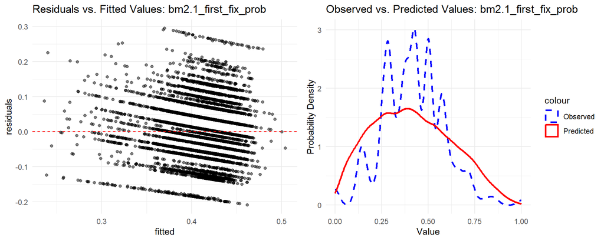

```r
p1 <- diag_resid_fitted(bm2.1_first_fix_prob)
p2 <- diag_ppc_beta(bm2.1_first_fix_prob)

grid.arrange(p1, p2, ncol = 2)
```

##### bm2.2_first_fix_prob

**Full model: Perfectionistic Concerns**

```r
bm2.2_first_fix_prob <- glmmTMB(
  first_fix_prob_t01 ~
    IA_LABEL_f * Perf_Concerns_c +
    block_nr_c +
    Change_category01 +
    #(1 | block_id) +
    (1 + Change_category01 || subject_id),
  dispformula = ~ guessed_block_rule,
  family = beta_family(link = "logit"),
  data = na.omit(sub_et_qu),

)
summary(bm2.2_first_fix_prob)
```

```
##  Family: beta  ( logit )
## Formula:
## first_fix_prob_t01 ~ IA_LABEL_f * Perf_Concerns_c + block_nr_c +
##     Change_category01 + (1 + Change_category01 || subject_id)
## Dispersion:                          ~guessed_block_rule
## Data: na.omit(sub_et_qu)
##
##      AIC      BIC   logLik deviance df.resid
##  -3695.7  -3580.2   1863.9  -3727.7    10080
##
## Random effects:
##
## Conditional model:
##  Groups     Name              Variance Std.Dev. Corr
##  subject_id (Intercept)       0.007382 0.08592
##             Change_category01 0.040345 0.20086  0.00
## Number of obs: 10096, groups:  subject_id, 202
##
## Conditional model:
##                                     Estimate Std. Error z value Pr(>|z|)
## (Intercept)                        -0.307871   0.020414 -15.082  < 2e-16 ***
## IA_LABEL_fPositive                  0.071762   0.026880   2.670 0.007591 **
## IA_LABEL_fNegative                 -0.090517   0.026933  -3.361 0.000777 ***
## IA_LABEL_fSuccess                  -0.004478   0.026914  -0.166 0.867840
## IA_LABEL_fFailure                  -0.022007   0.026911  -0.818 0.413496
## Perf_Concerns_c                    -0.013161   0.008544  -1.540 0.123458
## block_nr_c                          0.007335   0.002964   2.475 0.013329 *
## Change_category01                  -0.177706   0.025671  -6.922 4.44e-12 ***
## IA_LABEL_fPositive:Perf_Concerns_c  0.005075   0.011420   0.444 0.656750
## IA_LABEL_fNegative:Perf_Concerns_c  0.008286   0.011436   0.725 0.468746
## IA_LABEL_fSuccess:Perf_Concerns_c   0.027595   0.011476   2.405 0.016190 *
## IA_LABEL_fFailure:Perf_Concerns_c  -0.001587   0.011438  -0.139 0.889678
## ---
## Signif. codes:  0 '***' 0.001 '**' 0.01 '*' 0.05 '.' 0.1 ' ' 1
##
## Dispersion model:
##                    Estimate Std. Error z value Pr(>|z|)
## (Intercept)         1.50921    0.03031   49.80   <2e-16 ***
## guessed_block_rule -0.02265    0.03342   -0.68    0.498
## ---
## Signif. codes:  0 '***' 0.001 '**' 0.01 '*' 0.05 '.' 0.1 ' ' 1
```

**Comparison of model fit (bm2.2 vs. bm1)**

```r
lrtest(bm1_first_fix_prob, bm2.2_first_fix_prob)
```

```
## Likelihood ratio test
##
## Model 1: first_fix_prob_t01 ~ IA_LABEL_f + block_nr_c + Change_category01 +
##     (1 + Change_category01 || subject_id)
## Model 2: first_fix_prob_t01 ~ IA_LABEL_f * Perf_Concerns_c + block_nr_c +
##     Change_category01 + (1 + Change_category01 || subject_id)
##   #Df LogLik Df  Chisq Pr(>Chisq)
## 1  11 1859.0
## 2  16 1863.9  5 9.6719    0.08508 .
## ---
## Signif. codes:  0 '***' 0.001 '**' 0.01 '*' 0.05 '.' 0.1 ' ' 1
```

```r
AIC(bm2.2_first_fix_prob, bm1_first_fix_prob)
```

```
##                      df       AIC
## bm2.2_first_fix_prob 16 -3695.723
## bm1_first_fix_prob   11 -3696.051
```

The Strivings model improved fit and was therefore followed up using estimated perfectionism slopes within each semantic category and the four planned comparisons among those slopes. The Concerns model did not significantly improve fit and was not followed up.

```r
first_fix_prob_strivings_slopes <- emtrends(
  bm2.1_first_fix_prob,
  ~ IA_LABEL_f,
  var = "Perf_Strivings_c"
)
summary(first_fix_prob_strivings_slopes, infer = c(TRUE, TRUE))
```

```
##  IA_LABEL_f Perf_Strivings_c.trend     SE  df asymp.LCL asymp.UCL z.ratio
##  Neutral                  -0.02264 0.0111 Inf   -0.0444 -0.000854  -2.037
##  Positive                 -0.00215 0.0111 Inf   -0.0239  0.019574  -0.194
##  Negative                 -0.02749 0.0111 Inf   -0.0493 -0.005711  -2.474
##  Success                   0.00692 0.0111 Inf   -0.0148  0.028625   0.625
##  Failure                  -0.01756 0.0111 Inf   -0.0393  0.004161  -1.584
##  p.value
##   0.0417
##   0.8465
##   0.0134
##   0.5320
##   0.1131
##
## Results are averaged over the levels of: Change_category01
## Confidence level used: 0.95
```

```r
first_fix_prob_planned_slopes <- contrast(
  first_fix_prob_strivings_slopes,
  method = semantic_planned,
  adjust = "none"
)
first_fix_prob_planned_slopes
```

```
##  contrast                           estimate     SE  df z.ratio p.value
##  positive_vs_negative                -0.0498 0.0211 Inf  -2.367  0.0179
##  success_vs_failure                  -0.0245 0.0149 Inf  -1.646  0.0998
##  performance_irrelevant_vs_relevant   0.0726 0.0576 Inf   1.260  0.2076
##  neutral_vs_nonneutral                0.0503 0.0472 Inf   1.066  0.2865
##
## Results are averaged over the levels of: Change_category01
```

**Plotting the retained interaction**

```r
preds_first_fix_prob_PS <- ggpredict(
  bm2.1_first_fix_prob,
  terms = c("Perf_Strivings_c [all]", "IA_LABEL_f")
)

p_first_fix_data <- as.data.frame(preds_first_fix_prob_PS) %>%
  mutate(
    group = factor(as.character(group), levels = semantic_levels),
    supported = as.character(group) %in% c("Neutral", "Negative")
  )
stopifnot(
  !anyNA(p_first_fix_data$group),
  setequal(as.character(unique(p_first_fix_data$group)), semantic_levels)
)

p_first_fix_categories <- ggplot(
  p_first_fix_data,
  aes(x = x, y = predicted, group = group, color = group,
      linewidth = supported, alpha = supported)
) +
  geom_line() +
  scale_color_manual(values = semantic_colors, breaks = semantic_levels,
                     labels = semantic_levels, drop = FALSE) +
  scale_linewidth_manual(values = c(`FALSE` = 0.65, `TRUE` = 1), guide = "none") +
  scale_alpha_manual(values = c(`FALSE` = 0.65, `TRUE` = 1), guide = "none") +
  labs(
    title = NULL,
    x = "Perfectionistic Strivings",
    y = "Predicted proportion",
    color = "Semantic category"
  ) +
  figure3_theme +
  theme(
    plot.title = element_text(face = "bold"),
    axis.title.y = element_blank()
  )
```

```r
# Values spanning the observed range of Strivings
strivings_grid <- seq(
  min(sub_et_qu$Perf_Strivings_c, na.rm = TRUE),
  max(sub_et_qu$Perf_Strivings_c, na.rm = TRUE),
  length.out = 100
)

# Estimated category means at each value of Strivings
first_fix_emm <- emmeans(
  bm2.1_first_fix_prob,
  ~ IA_LABEL_f | Perf_Strivings_c,
  at = list(Perf_Strivings_c = strivings_grid)
)

# Move predictions to the probability scale before calculating differences
first_fix_emm_response <- regrid(
  first_fix_emm,
  transform = "response"
)

# Calculate the four theoretical contrasts
first_fix_contrasts <- contrast(
  first_fix_emm_response,
  method = semantic_planned,
  by = "Perf_Strivings_c",
  adjust = "none"
)

first_fix_contrasts_df <- as.data.frame(first_fix_contrasts) %>%
  mutate(contrast = factor(as.character(contrast), levels = names(contrast_colors)))
stopifnot(
  !anyNA(first_fix_contrasts_df$contrast),
  setequal(as.character(unique(first_fix_contrasts_df$contrast)), names(contrast_colors))
)
first_fix_supported_contrasts <- as.data.frame(first_fix_prob_planned_slopes) %>%
  filter(p.value < .05) %>%
  pull(contrast)
first_fix_contrasts_df$supported <-
  first_fix_contrasts_df$contrast %in% first_fix_supported_contrasts
```

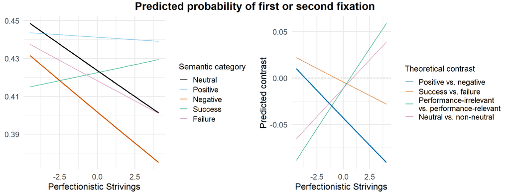

```r
p_first_fix_contrasts <- ggplot(
  first_fix_contrasts_df,
  aes(
    x = Perf_Strivings_c,
    y = estimate,
    color = contrast,
    group = contrast,
    linewidth = supported,
    alpha = supported
  )
) +
  geom_hline(
    yintercept = 0,
    color = "grey60",
    linetype = "dashed"
  ) +
  geom_line() +
  scale_color_manual(values = contrast_colors, breaks = names(contrast_colors),
                     labels = contrast_labels) +
  scale_linewidth_manual(values = c(`FALSE` = 0.65, `TRUE` = 1), guide = "none") +
  scale_alpha_manual(values = c(`FALSE` = 0.65, `TRUE` = 1), guide = "none") +
  labs(
    title = NULL,
    x = "Perfectionistic Strivings",
    y = "Predicted contrast",
    color = "Theoretical contrast"
  ) +
  figure3_theme +
  theme(
    plot.title = element_text(face = "bold"),
    legend.position = "right"
  )

grid.arrange(
  p_first_fix_categories, p_first_fix_contrasts,
  ncol = 2,
  top = textGrob(
    "Predicted probability of first or second fixation",
    gp = gpar(fontface = "bold", fontsize = 20)
  )
)
```

_________________________________________________________________

### 2. Latency to First Fixation

Latency to first fixation was modeled using a **beta GLMM** with a logit link for the mean parameter.

##### bm0_first_fix_latency

**Null model**

```r
bm0_first_fix_latency <- glmmTMB(
  first_fix_latency_t01 ~
    block_nr_c +
    Change_category01 +
    #(1 | block_id) +
    (1 + Change_category01 || subject_id),
  dispformula = ~ guessed_block_rule,
  family = beta_family(link = "logit"),
  data = na.omit(sub_et_qu),

)
summary(bm0_first_fix_latency)
```

```
##  Family: beta  ( logit )
## Formula:
## first_fix_latency_t01 ~ block_nr_c + Change_category01 + (1 +
##     Change_category01 || subject_id)
## Dispersion:                             ~guessed_block_rule
## Data: na.omit(sub_et_qu)
##
##      AIC      BIC   logLik deviance df.resid
## -46605.7 -46555.2  23309.9 -46619.7    10089
##
## Random effects:
##
## Conditional model:
##  Groups     Name              Variance  Std.Dev.  Corr
##  subject_id (Intercept)       1.979e-12 1.407e-06
##             Change_category01 2.129e-10 1.459e-05 0.00
## Number of obs: 10096, groups:  subject_id, 202
##
## Conditional model:
##                     Estimate Std. Error z value Pr(>|z|)
## (Intercept)       -1.391e+00  1.678e-03  -828.8  < 2e-16 ***
## block_nr_c        -2.919e-05  5.205e-04    -0.1    0.955
## Change_category01  2.601e-02  3.723e-03     7.0 2.83e-12 ***
## ---
## Signif. codes:  0 '***' 0.001 '**' 0.01 '*' 0.05 '.' 0.1 ' ' 1
##
## Dispersion model:
##                    Estimate Std. Error z value Pr(>|z|)
## (Intercept)         5.57289    0.03279  169.97   <2e-16 ***
## guessed_block_rule  0.05050    0.03627    1.39    0.164
## ---
## Signif. codes:  0 '***' 0.001 '**' 0.01 '*' 0.05 '.' 0.1 ' ' 1
```

##### bm1_first_fix_latency

**Partial Model**

```r
bm1_first_fix_latency <- glmmTMB(
  first_fix_latency_t01 ~
    IA_LABEL_f +
    block_nr_c +
    Change_category01 +
    #(1 | block_id) +
    (1 + Change_category01 || subject_id),
  dispformula = ~ guessed_block_rule,
  family = beta_family(link = "logit"),
  data = na.omit(sub_et_qu)
)
summary(bm1_first_fix_latency)
```

```
##  Family: beta  ( logit )
## Formula:
## first_fix_latency_t01 ~ IA_LABEL_f + block_nr_c + Change_category01 +
##     (1 + Change_category01 || subject_id)
## Dispersion:                             ~guessed_block_rule
## Data: na.omit(sub_et_qu)
##
##      AIC      BIC   logLik deviance df.resid
## -46623.6 -46544.2  23322.8 -46645.6    10085
##
## Random effects:
##
## Conditional model:
##  Groups     Name              Variance  Std.Dev.  Corr
##  subject_id (Intercept)       3.967e-14 1.992e-07
##             Change_category01 2.324e-10 1.524e-05 0.00
## Number of obs: 10096, groups:  subject_id, 202
##
## Conditional model:
##                      Estimate Std. Error z value Pr(>|z|)
## (Intercept)        -1.393e+00  3.429e-03  -406.2  < 2e-16 ***
## IA_LABEL_fPositive -9.341e-03  4.735e-03    -2.0   0.0485 *
## IA_LABEL_fNegative  1.153e-02  4.720e-03     2.4   0.0146 *
## IA_LABEL_fSuccess  -1.498e-03  4.729e-03    -0.3   0.7515
## IA_LABEL_fFailure   9.366e-03  4.722e-03     2.0   0.0473 *
## block_nr_c         -2.794e-05  5.199e-04    -0.1   0.9571
## Change_category01   2.599e-02  3.718e-03     7.0 2.73e-12 ***
## ---
## Signif. codes:  0 '***' 0.001 '**' 0.01 '*' 0.05 '.' 0.1 ' ' 1
##
## Dispersion model:
##                    Estimate Std. Error z value Pr(>|z|)
## (Intercept)         5.57889    0.03280  170.09   <2e-16 ***
## guessed_block_rule  0.04630    0.03628    1.28    0.202
## ---
## Signif. codes:  0 '***' 0.001 '**' 0.01 '*' 0.05 '.' 0.1 ' ' 1
```

**Comparison of model fit (bm1 vs. bm0)**

```r
lrtest(bm0_first_fix_latency, bm1_first_fix_latency)
```

```
## Likelihood ratio test
##
## Model 1: first_fix_latency_t01 ~ block_nr_c + Change_category01 + (1 +
##     Change_category01 || subject_id)
## Model 2: first_fix_latency_t01 ~ IA_LABEL_f + block_nr_c + Change_category01 +
##     (1 + Change_category01 || subject_id)
##   #Df LogLik Df  Chisq Pr(>Chisq)
## 1   7  23310
## 2  11  23323  4 25.921  3.283e-05 ***
## ---
## Signif. codes:  0 '***' 0.001 '**' 0.01 '*' 0.05 '.' 0.1 ' ' 1
```

```r
AIC(bm1_first_fix_latency, bm0_first_fix_latency)
```

```
##                       df       AIC
## bm1_first_fix_latency 11 -46623.64
## bm0_first_fix_latency  7 -46605.72
```

**Model diagnostics (bm1)**

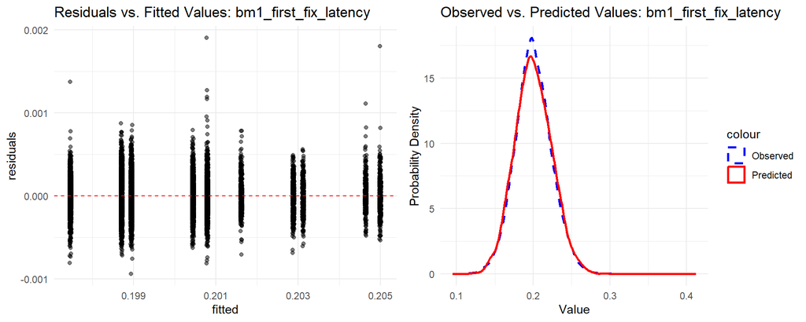

```r
p1 <- diag_resid_fitted(bm1_first_fix_latency)
p2 <- diag_ppc_beta(bm1_first_fix_latency)

grid.arrange(p1, p2, ncol = 2)
```

##### bm2.1_first_fix_latency

**Full model: Perfectionistic Strivings**

```r
bm2.1_first_fix_latency <- glmmTMB(
  first_fix_latency_t01 ~
    IA_LABEL_f * Perf_Strivings_c +
    block_nr_c +
    Change_category01 +
    #(1 | block_id) +
    (1 + Change_category01 || subject_id),
  dispformula = ~ guessed_block_rule,
  family = beta_family(link = "logit"),
  data = na.omit(sub_et_qu),

)
summary(bm2.1_first_fix_latency)
```

```
##  Family: beta  ( logit )
## Formula:
## first_fix_latency_t01 ~ IA_LABEL_f * Perf_Strivings_c + block_nr_c +
##     Change_category01 + (1 + Change_category01 || subject_id)
## Dispersion:                             ~guessed_block_rule
## Data: na.omit(sub_et_qu)
##
##      AIC      BIC   logLik deviance df.resid
## -46615.8 -46500.3  23323.9 -46647.8    10080
##
## Random effects:
##
## Conditional model:
##  Groups     Name              Variance  Std.Dev.  Corr
##  subject_id (Intercept)       7.844e-14 2.801e-07
##             Change_category01 2.738e-10 1.655e-05 0.00
## Number of obs: 10096, groups:  subject_id, 202
##
## Conditional model:
##                                       Estimate Std. Error z value Pr(>|z|)
## (Intercept)                         -1.393e+00  3.429e-03  -406.2  < 2e-16 ***
## IA_LABEL_fPositive                  -9.338e-03  4.735e-03    -2.0   0.0486 *
## IA_LABEL_fNegative                   1.153e-02  4.719e-03     2.4   0.0146 *
## IA_LABEL_fSuccess                   -1.495e-03  4.729e-03    -0.3   0.7519
## IA_LABEL_fFailure                    9.370e-03  4.722e-03     2.0   0.0472 *
## Perf_Strivings_c                    -1.328e-03  1.851e-03    -0.7   0.4731
## block_nr_c                          -2.635e-05  5.199e-04    -0.1   0.9596
## Change_category01                    2.599e-02  3.718e-03     7.0 2.72e-12 ***
## IA_LABEL_fPositive:Perf_Strivings_c  3.164e-03  2.623e-03     1.2   0.2277
## IA_LABEL_fNegative:Perf_Strivings_c  2.560e-04  2.615e-03     0.1   0.9220
## IA_LABEL_fSuccess:Perf_Strivings_c   1.704e-03  2.620e-03     0.7   0.5154
## IA_LABEL_fFailure:Perf_Strivings_c   2.323e-03  2.615e-03     0.9   0.3744
## ---
## Signif. codes:  0 '***' 0.001 '**' 0.01 '*' 0.05 '.' 0.1 ' ' 1
##
## Dispersion model:
##                    Estimate Std. Error z value Pr(>|z|)
## (Intercept)         5.57910    0.03282  169.98   <2e-16 ***
## guessed_block_rule  0.04631    0.03631    1.28    0.202
## ---
## Signif. codes:  0 '***' 0.001 '**' 0.01 '*' 0.05 '.' 0.1 ' ' 1
```

**Comparison of model fit (bm2.1 vs. bm1)**

```r
lrtest(bm1_first_fix_latency, bm2.1_first_fix_latency)
```

```
## Likelihood ratio test
##
## Model 1: first_fix_latency_t01 ~ IA_LABEL_f + block_nr_c + Change_category01 +
##     (1 + Change_category01 || subject_id)
## Model 2: first_fix_latency_t01 ~ IA_LABEL_f * Perf_Strivings_c + block_nr_c +
##     Change_category01 + (1 + Change_category01 || subject_id)
##   #Df LogLik Df  Chisq Pr(>Chisq)
## 1  11  23323
## 2  16  23324  5 2.1585     0.8268
```

```r
AIC(bm2.1_first_fix_latency, bm1_first_fix_latency)
```

```
##                         df       AIC
## bm2.1_first_fix_latency 16 -46615.80
## bm1_first_fix_latency   11 -46623.64
```

##### bm2.2_first_fix_latency

**Full model: Perfectionistic Concerns**

```r
bm2.2_first_fix_latency <- glmmTMB(
  first_fix_latency_t01 ~
    IA_LABEL_f * Perf_Concerns_c +
    block_nr_c +
    Change_category01 +
    #(1 | block_id) +
    (1 + Change_category01 || subject_id),
  dispformula = ~ guessed_block_rule,
  family = beta_family(link = "logit"),
  data = na.omit(sub_et_qu),

)
summary(bm2.2_first_fix_latency)
```

```
##  Family: beta  ( logit )
## Formula:
## first_fix_latency_t01 ~ IA_LABEL_f * Perf_Concerns_c + block_nr_c +
##     Change_category01 + (1 + Change_category01 || subject_id)
## Dispersion:                             ~guessed_block_rule
## Data: na.omit(sub_et_qu)
##
##      AIC      BIC   logLik deviance df.resid
## -46615.4 -46499.9  23323.7 -46647.4    10080
##
## Random effects:
##
## Conditional model:
##  Groups     Name              Variance  Std.Dev.  Corr
##  subject_id (Intercept)       6.072e-12 2.464e-06
##             Change_category01 1.049e-10 1.024e-05 0.00
## Number of obs: 10096, groups:  subject_id, 202
##
## Conditional model:
##                                      Estimate Std. Error z value Pr(>|z|)
## (Intercept)                        -1.393e+00  3.429e-03  -406.2  < 2e-16 ***
## IA_LABEL_fPositive                 -9.340e-03  4.735e-03    -2.0   0.0485 *
## IA_LABEL_fNegative                  1.153e-02  4.719e-03     2.4   0.0146 *
## IA_LABEL_fSuccess                  -1.497e-03  4.729e-03    -0.3   0.7515
## IA_LABEL_fFailure                   9.367e-03  4.722e-03     2.0   0.0473 *
## Perf_Concerns_c                     1.334e-04  1.421e-03     0.1   0.9252
## block_nr_c                         -2.702e-05  5.199e-04    -0.1   0.9585
## Change_category01                   2.599e-02  3.718e-03     7.0 2.74e-12 ***
## IA_LABEL_fPositive:Perf_Concerns_c  1.172e-03  2.012e-03     0.6   0.5604
## IA_LABEL_fNegative:Perf_Concerns_c -1.201e-03  2.007e-03    -0.6   0.5494
## IA_LABEL_fSuccess:Perf_Concerns_c  -8.469e-04  2.010e-03    -0.4   0.6735
## IA_LABEL_fFailure:Perf_Concerns_c   3.057e-04  2.006e-03     0.2   0.8789
## ---
## Signif. codes:  0 '***' 0.001 '**' 0.01 '*' 0.05 '.' 0.1 ' ' 1
##
## Dispersion model:
##                    Estimate Std. Error z value Pr(>|z|)
## (Intercept)         5.57893    0.03281  170.06   <2e-16 ***
## guessed_block_rule  0.04647    0.03629    1.28      0.2
## ---
## Signif. codes:  0 '***' 0.001 '**' 0.01 '*' 0.05 '.' 0.1 ' ' 1
```

**Comparison of model fit (bm2.2 vs. bm1)**

```r
lrtest(bm1_first_fix_latency, bm2.2_first_fix_latency)
```

```
## Likelihood ratio test
##
## Model 1: first_fix_latency_t01 ~ IA_LABEL_f + block_nr_c + Change_category01 +
##     (1 + Change_category01 || subject_id)
## Model 2: first_fix_latency_t01 ~ IA_LABEL_f * Perf_Concerns_c + block_nr_c +
##     Change_category01 + (1 + Change_category01 || subject_id)
##   #Df LogLik Df  Chisq Pr(>Chisq)
## 1  11  23323
## 2  16  23324  5 1.7631     0.8808
```

```r
AIC(bm2.2_first_fix_latency, bm1_first_fix_latency)
```

```
##                         df       AIC
## bm2.2_first_fix_latency 16 -46615.41
## bm1_first_fix_latency   11 -46623.64
```

_________________________________________________________________

### 3. Dwell Time (Early Phase)

Dwell time in the early phase was modeled using a **beta GLMM** with a logit link for the mean parameter.

##### bm0_dwell_time_early

**Null model**

```r
bm0_dwell_time_early <- glmmTMB(
  dwell_time_early_t01 ~
    block_nr_c +
    Change_category01 +
    #(1 | block_id) +
    (1 + Change_category01 || subject_id),
  dispformula = ~ guessed_block_rule,
  family = beta_family(link = "logit"),
  data = na.omit(sub_et_qu),

)
summary(bm0_dwell_time_early)
```

```
##  Family: beta  ( logit )
## Formula:          dwell_time_early_t01 ~ block_nr_c + Change_category01 + (1 +
##     Change_category01 || subject_id)
## Dispersion:                            ~guessed_block_rule
## Data: na.omit(sub_et_qu)
##
##      AIC      BIC   logLik deviance df.resid
## -17317.8 -17267.3   8665.9 -17331.8    10089
##
## Random effects:
##
## Conditional model:
##  Groups     Name              Variance Std.Dev. Corr
##  subject_id (Intercept)       0.01724  0.1313
##             Change_category01 0.02828  0.1682   0.00
## Number of obs: 10096, groups:  subject_id, 202
##
## Conditional model:
##                    Estimate Std. Error z value Pr(>|z|)
## (Intercept)       -1.414279   0.012034 -117.52   <2e-16 ***
## block_nr_c        -0.002334   0.002302   -1.01    0.311
## Change_category01  0.015338   0.020311    0.76    0.450
## ---
## Signif. codes:  0 '***' 0.001 '**' 0.01 '*' 0.05 '.' 0.1 ' ' 1
##
## Dispersion model:
##                    Estimate Std. Error z value Pr(>|z|)
## (Intercept)         2.50909    0.03203   78.33   <2e-16 ***
## guessed_block_rule -0.03171    0.03510   -0.90    0.366
## ---
## Signif. codes:  0 '***' 0.001 '**' 0.01 '*' 0.05 '.' 0.1 ' ' 1
```

##### bm1_dwell_time_early

**Partial Model**

```r
bm1_dwell_time_early <- glmmTMB(
  dwell_time_early_t01 ~
    IA_LABEL_f +
    block_nr_c +
    Change_category01 +
    #(1 | block_id) +
    (1 + Change_category01 || subject_id),
  dispformula = ~ guessed_block_rule,
  family = beta_family(link = "logit"),
  data = na.omit(sub_et_qu),

)
summary(bm1_dwell_time_early)
```

```
##  Family: beta  ( logit )
## Formula:
## dwell_time_early_t01 ~ IA_LABEL_f + block_nr_c + Change_category01 +
##     (1 + Change_category01 || subject_id)
## Dispersion:                            ~guessed_block_rule
## Data: na.omit(sub_et_qu)
##
##      AIC      BIC   logLik deviance df.resid
## -17321.0 -17241.6   8671.5 -17343.0    10085
##
## Random effects:
##
## Conditional model:
##  Groups     Name              Variance Std.Dev. Corr
##  subject_id (Intercept)       0.01713  0.1309
##             Change_category01 0.02843  0.1686   0.00
## Number of obs: 10096, groups:  subject_id, 202
##
## Conditional model:
##                     Estimate Std. Error z value Pr(>|z|)
## (Intercept)        -1.403550   0.017826  -78.74   <2e-16 ***
## IA_LABEL_fPositive  0.006796   0.020905    0.33   0.7451
## IA_LABEL_fNegative -0.047346   0.020964   -2.26   0.0239 *
## IA_LABEL_fSuccess  -0.024347   0.020922   -1.16   0.2445
## IA_LABEL_fFailure   0.011414   0.020849    0.55   0.5841
## block_nr_c         -0.002384   0.002302   -1.04   0.3002
## Change_category01   0.014664   0.020329    0.72   0.4707
## ---
## Signif. codes:  0 '***' 0.001 '**' 0.01 '*' 0.05 '.' 0.1 ' ' 1
##
## Dispersion model:
##                    Estimate Std. Error z value Pr(>|z|)
## (Intercept)         2.51318    0.03209   78.31   <2e-16 ***
## guessed_block_rule -0.03540    0.03518   -1.01    0.314
## ---
## Signif. codes:  0 '***' 0.001 '**' 0.01 '*' 0.05 '.' 0.1 ' ' 1
```

**Comparison of model fit (bm1 vs. bm0)**

```r
lrtest(bm1_dwell_time_early, bm0_dwell_time_early)
```

```
## Likelihood ratio test
##
## Model 1: dwell_time_early_t01 ~ IA_LABEL_f + block_nr_c + Change_category01 +
##     (1 + Change_category01 || subject_id)
## Model 2: dwell_time_early_t01 ~ block_nr_c + Change_category01 + (1 +
##     Change_category01 || subject_id)
##   #Df LogLik Df  Chisq Pr(>Chisq)
## 1  11 8671.5
## 2   7 8665.9 -4 11.132    0.02512 *
## ---
## Signif. codes:  0 '***' 0.001 '**' 0.01 '*' 0.05 '.' 0.1 ' ' 1
```

```r
AIC(bm1_dwell_time_early, bm0_dwell_time_early)
```

```
##                      df       AIC
## bm1_dwell_time_early 11 -17320.98
## bm0_dwell_time_early  7 -17317.85
```

##### bm2.1_dwell_time_early

**Full Model: Perfectionistic Strivings**

```r
bm2.1_dwell_time_early <- glmmTMB(
  dwell_time_early_t01 ~
    IA_LABEL_f * Perf_Strivings_c +
    block_nr_c +
    Change_category01 +
    #(1 | block_id) +
    (1 + Change_category01 || subject_id),
  dispformula = ~ guessed_block_rule,
  family = beta_family(link = "logit"),
  data = na.omit(sub_et_qu),

)
summary(bm2.1_dwell_time_early)
```

```
##  Family: beta  ( logit )
## Formula:
## dwell_time_early_t01 ~ IA_LABEL_f * Perf_Strivings_c + block_nr_c +
##     Change_category01 + (1 + Change_category01 || subject_id)
## Dispersion:                            ~guessed_block_rule
## Data: na.omit(sub_et_qu)
##
##      AIC      BIC   logLik deviance df.resid
## -17325.7 -17210.2   8678.8 -17357.7    10080
##
## Random effects:
##
## Conditional model:
##  Groups     Name              Variance Std.Dev. Corr
##  subject_id (Intercept)       0.01710  0.1307
##             Change_category01 0.02845  0.1687   0.00
## Number of obs: 10096, groups:  subject_id, 202
##
## Conditional model:
##                                      Estimate Std. Error z value Pr(>|z|)
## (Intercept)                         -1.403532   0.017813  -78.79  < 2e-16 ***
## IA_LABEL_fPositive                   0.006641   0.020894    0.32  0.75062
## IA_LABEL_fNegative                  -0.047412   0.020953   -2.26  0.02365 *
## IA_LABEL_fSuccess                   -0.024414   0.020911   -1.17  0.24299
## IA_LABEL_fFailure                    0.011278   0.020838    0.54  0.58834
## Perf_Strivings_c                     0.013458   0.009689    1.39  0.16481
## block_nr_c                          -0.002254   0.002301   -0.98  0.32711
## Change_category01                    0.014152   0.020326    0.70  0.48626
## IA_LABEL_fPositive:Perf_Strivings_c -0.030077   0.011564   -2.60  0.00930 **
## IA_LABEL_fNegative:Perf_Strivings_c -0.006453   0.011575   -0.56  0.57715
## IA_LABEL_fSuccess:Perf_Strivings_c  -0.036331   0.011541   -3.15  0.00164 **
## IA_LABEL_fFailure:Perf_Strivings_c  -0.013436   0.011565   -1.16  0.24529
## ---
## Signif. codes:  0 '***' 0.001 '**' 0.01 '*' 0.05 '.' 0.1 ' ' 1
##
## Dispersion model:
##                    Estimate Std. Error z value Pr(>|z|)
## (Intercept)         2.51478    0.03212   78.29   <2e-16 ***
## guessed_block_rule -0.03552    0.03523   -1.01    0.313
## ---
## Signif. codes:  0 '***' 0.001 '**' 0.01 '*' 0.05 '.' 0.1 ' ' 1
```

**Comparison of model fit (bm2.1 vs. bm1)**

```r
lrtest(bm2.1_dwell_time_early, bm1_dwell_time_early)
```

```
## Likelihood ratio test
##
## Model 1: dwell_time_early_t01 ~ IA_LABEL_f * Perf_Strivings_c + block_nr_c +
##     Change_category01 + (1 + Change_category01 || subject_id)
## Model 2: dwell_time_early_t01 ~ IA_LABEL_f + block_nr_c + Change_category01 +
##     (1 + Change_category01 || subject_id)
##   #Df LogLik Df  Chisq Pr(>Chisq)
## 1  16 8678.8
## 2  11 8671.5 -5 14.699    0.01173 *
## ---
## Signif. codes:  0 '***' 0.001 '**' 0.01 '*' 0.05 '.' 0.1 ' ' 1
```

```r
AIC(bm2.1_dwell_time_early, bm1_dwell_time_early)
```

```
##                        df       AIC
## bm2.1_dwell_time_early 16 -17325.68
## bm1_dwell_time_early   11 -17320.98
```

**Model diagnostics (bm2.1)**

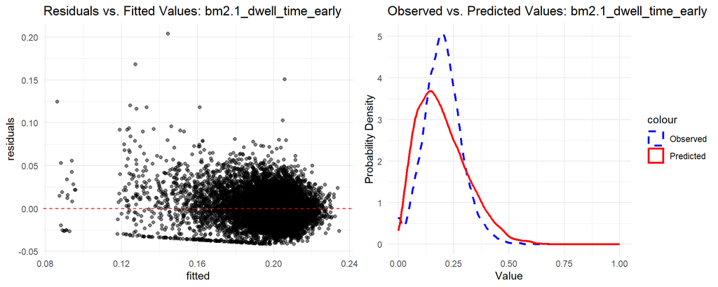

```r
p1 <- diag_resid_fitted(bm2.1_dwell_time_early)
p2 <- diag_ppc_beta(bm2.1_dwell_time_early)

grid.arrange(p1, p2, ncol = 2)
```

**Planned comparisons of the retained interaction**

The supported Strivings interaction was examined using estimated Strivings slopes within each semantic category and the four theory-based comparisons among those slopes. No models were refitted with alternative reference levels.

```r
early_dwell_strivings_slopes <- emtrends(
  bm2.1_dwell_time_early,
  ~ IA_LABEL_f,
  var = "Perf_Strivings_c"
)
summary(early_dwell_strivings_slopes, infer = c(TRUE, TRUE))
```

```
##  IA_LABEL_f Perf_Strivings_c.trend      SE  df asymp.LCL asymp.UCL z.ratio
##  Neutral                  0.013458 0.00969 Inf  -0.00553   0.03245   1.389
##  Positive                -0.016619 0.00969 Inf  -0.03561   0.00237  -1.715
##  Negative                 0.007005 0.00970 Inf  -0.01200   0.02601   0.722
##  Success                 -0.022873 0.00967 Inf  -0.04182  -0.00393  -2.366
##  Failure                  0.000022 0.00969 Inf  -0.01897   0.01901   0.002
##  p.value
##   0.1648
##   0.0863
##   0.4701
##   0.0180
##   0.9982
##
## Results are averaged over the levels of: Change_category01
## Confidence level used: 0.95
```

```r
early_dwell_planned_slopes <- contrast(
  early_dwell_strivings_slopes,
  method = semantic_planned,
  adjust = "none"
)
early_dwell_planned_slopes
```

```
##  contrast                           estimate     SE  df z.ratio p.value
##  positive_vs_negative                 0.0465 0.0163 Inf   2.847  0.0044
##  success_vs_failure                   0.0229 0.0115 Inf   1.984  0.0473
##  performance_irrelevant_vs_relevant  -0.0762 0.0447 Inf  -1.705  0.0882
##  neutral_vs_nonneutral               -0.0863 0.0366 Inf  -2.360  0.0183
##
## Results are averaged over the levels of: Change_category01
```

##### bm2.2_dwell_time_early

**Full Model: Perfectionistic Concerns**

```r
bm2.2_dwell_time_early <- glmmTMB(
  dwell_time_early_t01 ~
    IA_LABEL_f * Perf_Concerns_c +
    block_nr_c +
    Change_category01 +
    #(1 | block_id) +
    (1 + Change_category01 || subject_id),
  dispformula = ~ guessed_block_rule,
  family = beta_family(link = "logit"),
  data = na.omit(sub_et_qu),

)
summary(bm2.2_dwell_time_early)
```

```
##  Family: beta  ( logit )
## Formula:
## dwell_time_early_t01 ~ IA_LABEL_f * Perf_Concerns_c + block_nr_c +
##     Change_category01 + (1 + Change_category01 || subject_id)
## Dispersion:                            ~guessed_block_rule
## Data: na.omit(sub_et_qu)
##
##      AIC      BIC   logLik deviance df.resid
## -17315.8 -17200.3   8673.9 -17347.8    10080
##
## Random effects:
##
## Conditional model:
##  Groups     Name              Variance Std.Dev. Corr
##  subject_id (Intercept)       0.01699  0.1303
##             Change_category01 0.02846  0.1687   0.00
## Number of obs: 10096, groups:  subject_id, 202
##
## Conditional model:
##                                     Estimate Std. Error z value Pr(>|z|)
## (Intercept)                        -1.403474   0.017803  -78.83   <2e-16 ***
## IA_LABEL_fPositive                  0.006694   0.020902    0.32   0.7488
## IA_LABEL_fNegative                 -0.047482   0.020961   -2.27   0.0235 *
## IA_LABEL_fSuccess                  -0.024376   0.020919   -1.17   0.2439
## IA_LABEL_fFailure                   0.011280   0.020847    0.54   0.5884
## Perf_Concerns_c                     0.005557   0.007433    0.75   0.4547
## block_nr_c                         -0.002353   0.002301   -1.02   0.3065
## Change_category01                   0.014620   0.020330    0.72   0.4721
## IA_LABEL_fPositive:Perf_Concerns_c -0.005278   0.008887   -0.59   0.5526
## IA_LABEL_fNegative:Perf_Concerns_c -0.008747   0.008913   -0.98   0.3264
## IA_LABEL_fSuccess:Perf_Concerns_c  -0.018051   0.008916   -2.02   0.0429 *
## IA_LABEL_fFailure:Perf_Concerns_c  -0.010561   0.008859   -1.19   0.2332
## ---
## Signif. codes:  0 '***' 0.001 '**' 0.01 '*' 0.05 '.' 0.1 ' ' 1
##
## Dispersion model:
##                    Estimate Std. Error z value Pr(>|z|)
## (Intercept)         2.51232    0.03210   78.27   <2e-16 ***
## guessed_block_rule -0.03389    0.03519   -0.96    0.336
## ---
## Signif. codes:  0 '***' 0.001 '**' 0.01 '*' 0.05 '.' 0.1 ' ' 1
```

**Comparison of model fit (bm2.2 vs. bm1)**

```r
lrtest(bm2.2_dwell_time_early, bm1_dwell_time_early)
```

```
## Likelihood ratio test
##
## Model 1: dwell_time_early_t01 ~ IA_LABEL_f * Perf_Concerns_c + block_nr_c +
##     Change_category01 + (1 + Change_category01 || subject_id)
## Model 2: dwell_time_early_t01 ~ IA_LABEL_f + block_nr_c + Change_category01 +
##     (1 + Change_category01 || subject_id)
##   #Df LogLik Df  Chisq Pr(>Chisq)
## 1  16 8673.9
## 2  11 8671.5 -5 4.8473     0.4348
```

```r
AIC(bm2.2_dwell_time_early, bm1_dwell_time_early)
```

```
##                        df       AIC
## bm2.2_dwell_time_early 16 -17315.83
## bm1_dwell_time_early   11 -17320.98
```

**Plotting the retained interaction**

```r
preds_dwell_time_early_PS <- ggpredict(
  bm2.1_dwell_time_early,
  terms = c("Perf_Strivings_c [all]", "IA_LABEL_f")
)

p_early_dwell_data <- as.data.frame(preds_dwell_time_early_PS) %>%
  mutate(
    group = factor(as.character(group), levels = semantic_levels),
    supported = as.character(group) == "Success"
  )
stopifnot(
  !anyNA(p_early_dwell_data$group),
  setequal(as.character(unique(p_early_dwell_data$group)), semantic_levels)
)

p_early_dwell_categories <- ggplot(
  p_early_dwell_data,
  aes(x = x, y = predicted, group = group, color = group,
      linewidth = supported, alpha = supported)
) +
  geom_line() +
  scale_color_manual(values = semantic_colors, breaks = semantic_levels,
                     labels = semantic_levels, drop = FALSE) +
  scale_linewidth_manual(values = c(`FALSE` = 0.65, `TRUE` = 1), guide = "none") +
  scale_alpha_manual(values = c(`FALSE` = 0.65, `TRUE` = 1), guide = "none") +
  labs(
    title = NULL,
    x = "Perfectionistic Strivings",
    y = "Predicted proportion",
    color = "Semantic category"
  ) +
  figure3_theme +
  theme(
    plot.title = element_text(face = "bold"),
    axis.title.y = element_blank()
  )
```

```r
strivings_grid_early <- seq(
  min(sub_et_qu$Perf_Strivings_c, na.rm = TRUE),
  max(sub_et_qu$Perf_Strivings_c, na.rm = TRUE),
  length.out = 100
)

early_dwell_emm <- emmeans(
  bm2.1_dwell_time_early,
  ~ IA_LABEL_f | Perf_Strivings_c,
  at = list(Perf_Strivings_c = strivings_grid_early)
)

early_dwell_contrasts <- contrast(
  regrid(early_dwell_emm, transform = "response"),
  method = semantic_planned,
  by = "Perf_Strivings_c",
  adjust = "none"
)

early_dwell_contrasts_df <- as.data.frame(early_dwell_contrasts) %>%
  mutate(contrast = factor(as.character(contrast), levels = names(contrast_colors)))
stopifnot(
  !anyNA(early_dwell_contrasts_df$contrast),
  setequal(as.character(unique(early_dwell_contrasts_df$contrast)), names(contrast_colors))
)
early_dwell_supported_contrasts <- as.data.frame(early_dwell_planned_slopes) %>%
  filter(p.value < .05) %>%
  pull(contrast)
early_dwell_contrasts_df$supported <-
  early_dwell_contrasts_df$contrast %in% early_dwell_supported_contrasts
```

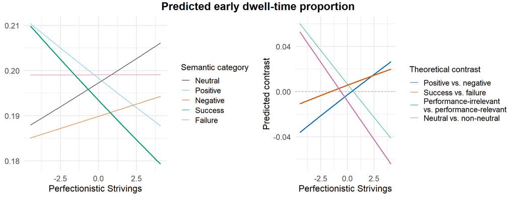

```r
p_early_dwell_contrasts <- ggplot(
  early_dwell_contrasts_df,
  aes(x = Perf_Strivings_c, y = estimate, color = contrast,
      group = contrast, linewidth = supported, alpha = supported)
) +
  geom_hline(yintercept = 0, color = "grey60", linetype = "dashed") +
  geom_line() +
  scale_color_manual(values = contrast_colors, breaks = names(contrast_colors),
                     labels = contrast_labels) +
  scale_linewidth_manual(values = c(`FALSE` = 0.65, `TRUE` = 1), guide = "none") +
  scale_alpha_manual(values = c(`FALSE` = 0.65, `TRUE` = 1), guide = "none") +
  labs(
    title = NULL,
    x = "Perfectionistic Strivings",
    y = "Predicted contrast",
    color = "Theoretical contrast"
  ) +
  figure3_theme +
  theme(
    plot.title = element_text(face = "bold"),
    legend.position = "right"
  )

grid.arrange(
  p_early_dwell_categories, p_early_dwell_contrasts,
  ncol = 2,
  top = textGrob(
    "Predicted early dwell-time proportion",
    gp = gpar(fontface = "bold", fontsize = 20)
  )
)
```

_________________________________________________________________

### 4. Dwell Time (Intermediate Phase)

Dwell time in the intermediate phase was modeled using a **beta GLMM** with a logit link for the mean parameter.

##### bm0_dwell_time_intermediate

**Null model**

```r
bm0_dwell_time_intermediate <- glmmTMB(
  dwell_time_intermediate_t01 ~
    block_nr_c +
    Change_category01 +
    #(1 | block_id) +
    (1 + Change_category01 || subject_id),
  dispformula = ~ guessed_block_rule,
  family = beta_family(link = "logit"),
  data = na.omit(sub_et_qu),

)
summary(bm0_dwell_time_intermediate)
```

```
##  Family: beta  ( logit )
## Formula:
## dwell_time_intermediate_t01 ~ block_nr_c + Change_category01 +
##     (1 + Change_category01 || subject_id)
## Dispersion:                                   ~guessed_block_rule
## Data: na.omit(sub_et_qu)
##
##      AIC      BIC   logLik deviance df.resid
## -25603.2 -25552.6  12808.6 -25617.2    10089
##
## Random effects:
##
## Conditional model:
##  Groups     Name              Variance Std.Dev. Corr
##  subject_id (Intercept)       0.01022  0.1011
##             Change_category01 0.17470  0.4180   0.00
## Number of obs: 10096, groups:  subject_id, 202
##
## Conditional model:
##                    Estimate Std. Error z value Pr(>|z|)
## (Intercept)       -1.448451   0.008577 -168.87  < 2e-16 ***
## block_nr_c        -0.002057   0.001452   -1.42    0.157
## Change_category01  0.249456   0.031109    8.02 1.07e-15 ***
## ---
## Signif. codes:  0 '***' 0.001 '**' 0.01 '*' 0.05 '.' 0.1 ' ' 1
##
## Dispersion model:
##                    Estimate Std. Error z value Pr(>|z|)
## (Intercept)        3.514764   0.033006  106.49   <2e-16 ***
## guessed_block_rule 0.008072   0.036692    0.22    0.826
## ---
## Signif. codes:  0 '***' 0.001 '**' 0.01 '*' 0.05 '.' 0.1 ' ' 1
```

##### bm1_dwell_time_intermediate:

**Partial Model**

```r
bm1_dwell_time_intermediate <- glmmTMB(
  dwell_time_intermediate_t01 ~
    IA_LABEL_f +
    block_nr_c +
    Change_category01 +
    #(1 | block_id) +
    (1 + Change_category01 || subject_id),
  dispformula = ~ guessed_block_rule,
  family = beta_family(link = "logit"),
  data = na.omit(sub_et_qu),

)
summary(bm1_dwell_time_intermediate)
```

```
##  Family: beta  ( logit )
## Formula:
## dwell_time_intermediate_t01 ~ IA_LABEL_f + block_nr_c + Change_category01 +
##     (1 + Change_category01 || subject_id)
## Dispersion:                                   ~guessed_block_rule
## Data: na.omit(sub_et_qu)
##
##      AIC      BIC   logLik deviance df.resid
## -25620.4 -25541.0  12821.2 -25642.4    10085
##
## Random effects:
##
## Conditional model:
##  Groups     Name              Variance Std.Dev. Corr
##  subject_id (Intercept)       0.01023  0.1011
##             Change_category01 0.17480  0.4181   0.00
## Number of obs: 10096, groups:  subject_id, 202
##
## Conditional model:
##                     Estimate Std. Error z value Pr(>|z|)
## (Intercept)        -1.476086   0.012015 -122.86  < 2e-16 ***
## IA_LABEL_fPositive  0.047575   0.013185    3.61 0.000308 ***
## IA_LABEL_fNegative  0.045617   0.013171    3.46 0.000533 ***
## IA_LABEL_fSuccess   0.039990   0.013189    3.03 0.002429 **
## IA_LABEL_fFailure   0.004066   0.013256    0.31 0.759055
## block_nr_c         -0.002053   0.001450   -1.42 0.156954
## Change_category01   0.249616   0.031112    8.02 1.03e-15 ***
## ---
## Signif. codes:  0 '***' 0.001 '**' 0.01 '*' 0.05 '.' 0.1 ' ' 1
##
## Dispersion model:
##                    Estimate Std. Error z value Pr(>|z|)
## (Intercept)        3.517992   0.033005   106.6   <2e-16 ***
## guessed_block_rule 0.007353   0.036690     0.2    0.841
## ---
## Signif. codes:  0 '***' 0.001 '**' 0.01 '*' 0.05 '.' 0.1 ' ' 1
```

**Comparison of model fit (bm1 vs. bm0)**

```r
lrtest(bm1_dwell_time_intermediate, bm0_dwell_time_intermediate)
```

```
## Likelihood ratio test
##
## Model 1: dwell_time_intermediate_t01 ~ IA_LABEL_f + block_nr_c + Change_category01 +
##     (1 + Change_category01 || subject_id)
## Model 2: dwell_time_intermediate_t01 ~ block_nr_c + Change_category01 +
##     (1 + Change_category01 || subject_id)
##   #Df LogLik Df  Chisq Pr(>Chisq)
## 1  11  12821
## 2   7  12809 -4 25.238  4.506e-05 ***
## ---
## Signif. codes:  0 '***' 0.001 '**' 0.01 '*' 0.05 '.' 0.1 ' ' 1
```

```r
AIC(bm1_dwell_time_intermediate, bm0_dwell_time_intermediate)
```

```
##                             df       AIC
## bm1_dwell_time_intermediate 11 -25620.40
## bm0_dwell_time_intermediate  7 -25603.16
```

##### bm2.1_dwell_time_intermediate

**Full Model: Perfectionistic Strivings**

```r
bm2.1_dwell_time_intermediate <- glmmTMB(
  dwell_time_intermediate_t01 ~
    IA_LABEL_f * Perf_Strivings_c +
    block_nr_c +
    Change_category01 +
    #(1 | block_id) +
    (1 + Change_category01 || subject_id),
  dispformula = ~ guessed_block_rule,
  family = beta_family(link = "logit"),
  data = na.omit(sub_et_qu),

)
summary(bm2.1_dwell_time_intermediate)
```

```
##  Family: beta  ( logit )
## Formula:
## dwell_time_intermediate_t01 ~ IA_LABEL_f * Perf_Strivings_c +
##     block_nr_c + Change_category01 + (1 + Change_category01 ||      subject_id)
## Dispersion:                                   ~guessed_block_rule
## Data: na.omit(sub_et_qu)
##
##      AIC      BIC   logLik deviance df.resid
## -25618.3 -25502.8  12825.1 -25650.3    10080
##
## Random effects:
##
## Conditional model:
##  Groups     Name              Variance Std.Dev. Corr
##  subject_id (Intercept)       0.01022  0.1011
##             Change_category01 0.17464  0.4179   0.00
## Number of obs: 10096, groups:  subject_id, 202
##
## Conditional model:
##                                      Estimate Std. Error z value Pr(>|z|)
## (Intercept)                         -1.476137   0.012010 -122.91  < 2e-16 ***
## IA_LABEL_fPositive                   0.047621   0.013181    3.61 0.000303 ***
## IA_LABEL_fNegative                   0.045650   0.013167    3.47 0.000526 ***
## IA_LABEL_fSuccess                    0.040011   0.013185    3.03 0.002408 **
## IA_LABEL_fFailure                    0.004078   0.013251    0.31 0.758296
## Perf_Strivings_c                    -0.003323   0.006634   -0.50 0.616398
## block_nr_c                          -0.002059   0.001450   -1.42 0.155647
## Change_category01                    0.249654   0.031099    8.03 9.92e-16 ***
## IA_LABEL_fPositive:Perf_Strivings_c  0.009496   0.007292    1.30 0.192851
## IA_LABEL_fNegative:Perf_Strivings_c -0.008446   0.007296   -1.16 0.247024
## IA_LABEL_fSuccess:Perf_Strivings_c   0.006964   0.007315    0.95 0.341070
## IA_LABEL_fFailure:Perf_Strivings_c   0.005933   0.007339    0.81 0.418852
## ---
## Signif. codes:  0 '***' 0.001 '**' 0.01 '*' 0.05 '.' 0.1 ' ' 1
##
## Dispersion model:
##                    Estimate Std. Error z value Pr(>|z|)
## (Intercept)        3.518766   0.033013   106.6   <2e-16 ***
## guessed_block_rule 0.007342   0.036701     0.2    0.841
## ---
## Signif. codes:  0 '***' 0.001 '**' 0.01 '*' 0.05 '.' 0.1 ' ' 1
```

**Comparison of model fit (bm2.1 vs. bm1)**

```r
lrtest(bm2.1_dwell_time_intermediate, bm1_dwell_time_intermediate)
```

```
## Likelihood ratio test
##
## Model 1: dwell_time_intermediate_t01 ~ IA_LABEL_f * Perf_Strivings_c +
##     block_nr_c + Change_category01 + (1 + Change_category01 ||
##     subject_id)
## Model 2: dwell_time_intermediate_t01 ~ IA_LABEL_f + block_nr_c + Change_category01 +
##     (1 + Change_category01 || subject_id)
##   #Df LogLik Df  Chisq Pr(>Chisq)
## 1  16  12825
## 2  11  12821 -5 7.8814     0.1629
```

```r
AIC(bm2.1_dwell_time_intermediate, bm1_dwell_time_intermediate)
```

```
##                               df       AIC
## bm2.1_dwell_time_intermediate 16 -25618.28
## bm1_dwell_time_intermediate   11 -25620.40
```

The Strivings model did not significantly improve fit and is not followed up.

##### bm2.2_dwell_time_intermediate

**Full Model: Perfectionistic Concerns**

```r
bm2.2_dwell_time_intermediate <- glmmTMB(
  dwell_time_intermediate_t01 ~
    IA_LABEL_f * Perf_Concerns_c +
    block_nr_c +
    Change_category01 +
    #(1 | block_id) +
    (1 + Change_category01 || subject_id),
  dispformula = ~ guessed_block_rule,
  family = beta_family(link = "logit"),
  data = na.omit(sub_et_qu),

)
summary(bm2.2_dwell_time_intermediate)
```

```
##  Family: beta  ( logit )
## Formula:          dwell_time_intermediate_t01 ~ IA_LABEL_f * Perf_Concerns_c +
##     block_nr_c + Change_category01 + (1 + Change_category01 ||      subject_id)
## Dispersion:                                   ~guessed_block_rule
## Data: na.omit(sub_et_qu)
##
##      AIC      BIC   logLik deviance df.resid
## -25628.1 -25512.6  12830.0 -25660.1    10080
##
## Random effects:
##
## Conditional model:
##  Groups     Name              Variance Std.Dev. Corr
##  subject_id (Intercept)       0.01014  0.1007
##             Change_category01 0.17479  0.4181   0.00
## Number of obs: 10096, groups:  subject_id, 202
##
## Conditional model:
##                                      Estimate Std. Error z value Pr(>|z|)
## (Intercept)                        -1.4761527  0.0119906 -123.11  < 2e-16 ***
## IA_LABEL_fPositive                  0.0475083  0.0131754    3.61 0.000311 ***
## IA_LABEL_fNegative                  0.0457207  0.0131608    3.47 0.000513 ***
## IA_LABEL_fSuccess                   0.0400043  0.0131795    3.04 0.002403 **
## IA_LABEL_fFailure                   0.0040342  0.0132464    0.30 0.760706
## Perf_Concerns_c                    -0.0006525  0.0050629   -0.13 0.897452
## block_nr_c                         -0.0020328  0.0014493   -1.40 0.160730
## Change_category01                   0.2495815  0.0311089    8.02 1.03e-15 ***
## IA_LABEL_fPositive:Perf_Concerns_c -0.0084764  0.0055765   -1.52 0.128505
## IA_LABEL_fNegative:Perf_Concerns_c -0.0141761  0.0055750   -2.54 0.010996 *
## IA_LABEL_fSuccess:Perf_Concerns_c   0.0030117  0.0055901    0.54 0.590059
## IA_LABEL_fFailure:Perf_Concerns_c   0.0045606  0.0055967    0.81 0.415146
## ---
## Signif. codes:  0 '***' 0.001 '**' 0.01 '*' 0.05 '.' 0.1 ' ' 1
##
## Dispersion model:
##                    Estimate Std. Error z value Pr(>|z|)
## (Intercept)        3.518037   0.033011  106.57   <2e-16 ***
## guessed_block_rule 0.009355   0.036703    0.25    0.799
## ---
## Signif. codes:  0 '***' 0.001 '**' 0.01 '*' 0.05 '.' 0.1 ' ' 1
```

**Comparison of model fit (bm2.2 vs. bm1)**

```r
lrtest(bm2.2_dwell_time_intermediate, bm1_dwell_time_intermediate)
```

```
## Likelihood ratio test
##
## Model 1: dwell_time_intermediate_t01 ~ IA_LABEL_f * Perf_Concerns_c +
##     block_nr_c + Change_category01 + (1 + Change_category01 ||
##     subject_id)
## Model 2: dwell_time_intermediate_t01 ~ IA_LABEL_f + block_nr_c + Change_category01 +
##     (1 + Change_category01 || subject_id)
##   #Df LogLik Df  Chisq Pr(>Chisq)
## 1  16  12830
## 2  11  12821 -5 17.688   0.003364 **
## ---
## Signif. codes:  0 '***' 0.001 '**' 0.01 '*' 0.05 '.' 0.1 ' ' 1
```

```r
AIC(bm2.2_dwell_time_intermediate, bm1_dwell_time_intermediate)
```

```
##                               df       AIC
## bm2.2_dwell_time_intermediate 16 -25628.09
## bm1_dwell_time_intermediate   11 -25620.40
```

**Model diagnostics (bm2.2)**

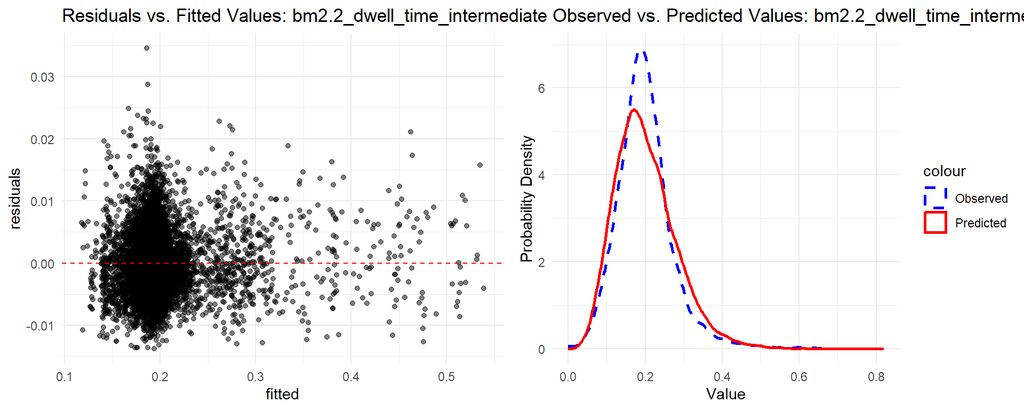

```r
p1 <- diag_resid_fitted(bm2.2_dwell_time_intermediate)
p2 <- diag_ppc_beta(bm2.2_dwell_time_intermediate)

grid.arrange(p1, p2, ncol = 2)
```

**Planned comparisons of the retained interaction**

The supported Concerns interaction was examined using estimated Concerns slopes within each semantic category and the four theory-based comparisons among those slopes.

```r
intermediate_dwell_concerns_slopes <- emtrends(
  bm2.2_dwell_time_intermediate,
  ~ IA_LABEL_f,
  var = "Perf_Concerns_c"
)
summary(intermediate_dwell_concerns_slopes, infer = c(TRUE, TRUE))
```

```
##  IA_LABEL_f Perf_Concerns_c.trend      SE  df asymp.LCL asymp.UCL z.ratio
##  Neutral                -0.000653 0.00506 Inf  -0.01058  0.009271  -0.129
##  Positive               -0.009129 0.00503 Inf  -0.01899  0.000736  -1.814
##  Negative               -0.014829 0.00502 Inf  -0.02468 -0.004981  -2.951
##  Success                 0.002359 0.00504 Inf  -0.00752  0.012242   0.468
##  Failure                 0.003908 0.00505 Inf  -0.00599  0.013806   0.774
##  p.value
##   0.8975
##   0.0697
##   0.0032
##   0.6399
##   0.4390
##
## Results are averaged over the levels of: Change_category01
## Confidence level used: 0.95
```

```r
intermediate_dwell_planned_slopes <- contrast(
  intermediate_dwell_concerns_slopes,
  method = semantic_planned,
  adjust = "none"
)
intermediate_dwell_planned_slopes
```

```
##  contrast                           estimate      SE  df z.ratio p.value
##  positive_vs_negative               -0.00415 0.00787 Inf  -0.527  0.5979
##  success_vs_failure                  0.00155 0.00558 Inf   0.278  0.7814
##  performance_irrelevant_vs_relevant  0.06802 0.02160 Inf   3.149  0.0016
##  neutral_vs_nonneutral              -0.01508 0.01770 Inf  -0.852  0.3941
##
## Results are averaged over the levels of: Change_category01
```

**Plotting the retained interaction**

```r
preds_dwell_time_intermediate_PC <- ggpredict(
  bm2.2_dwell_time_intermediate,
  terms = c("Perf_Concerns_c [all]", "IA_LABEL_f")
)

p_intermediate_dwell_data <- as.data.frame(preds_dwell_time_intermediate_PC) %>%
  mutate(
    group = factor(as.character(group), levels = semantic_levels),
    supported = as.character(group) == "Negative"
  )
stopifnot(
  !anyNA(p_intermediate_dwell_data$group),
  setequal(as.character(unique(p_intermediate_dwell_data$group)), semantic_levels)
)

p_intermediate_dwell_categories <- ggplot(
  p_intermediate_dwell_data,
  aes(x = x, y = predicted, group = group, color = group,
      linewidth = supported, alpha = supported)
) +
  geom_line() +
  scale_color_manual(values = semantic_colors, breaks = semantic_levels,
                     labels = semantic_levels, drop = FALSE) +
  scale_linewidth_manual(values = c(`FALSE` = 0.65, `TRUE` = 1), guide = "none") +
  scale_alpha_manual(values = c(`FALSE` = 0.65, `TRUE` = 1), guide = "none") +
  labs(
    title = NULL,
    x = "Perfectionistic Concerns",
    y = "Predicted proportion",
    color = "Semantic category"
  ) +
  figure3_theme +
  theme(
    plot.title = element_text(face = "bold"),
    axis.title.y = element_blank()
  )
```

```r
concerns_grid_intermediate <- seq(
  min(sub_et_qu$Perf_Concerns_c, na.rm = TRUE),
  max(sub_et_qu$Perf_Concerns_c, na.rm = TRUE),
  length.out = 100
)

intermediate_dwell_emm <- emmeans(
  bm2.2_dwell_time_intermediate,
  ~ IA_LABEL_f | Perf_Concerns_c,
  at = list(Perf_Concerns_c = concerns_grid_intermediate)
)

intermediate_dwell_contrasts <- contrast(
  regrid(intermediate_dwell_emm, transform = "response"),
  method = semantic_planned,
  by = "Perf_Concerns_c",
  adjust = "none"
)

intermediate_dwell_contrasts_df <- as.data.frame(
  intermediate_dwell_contrasts
) %>%
  mutate(contrast = factor(as.character(contrast), levels = names(contrast_colors)))
stopifnot(
  !anyNA(intermediate_dwell_contrasts_df$contrast),
  setequal(as.character(unique(intermediate_dwell_contrasts_df$contrast)),
           names(contrast_colors))
)
intermediate_dwell_supported_contrasts <-
  as.data.frame(intermediate_dwell_planned_slopes) %>%
  filter(p.value < .05) %>%
  pull(contrast)
intermediate_dwell_contrasts_df$supported <-
  intermediate_dwell_contrasts_df$contrast %in%
  intermediate_dwell_supported_contrasts
```

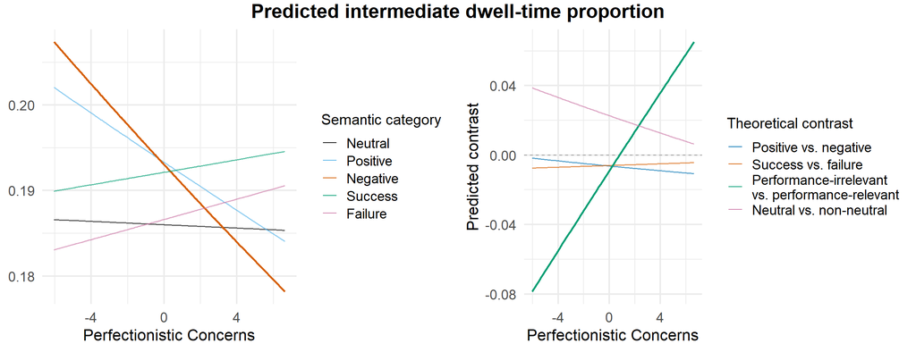

```r
p_intermediate_dwell_contrasts <- ggplot(
  intermediate_dwell_contrasts_df,
  aes(x = Perf_Concerns_c, y = estimate, color = contrast,
      group = contrast, linewidth = supported, alpha = supported)
) +
  geom_hline(yintercept = 0, color = "grey60", linetype = "dashed") +
  geom_line() +
  scale_color_manual(values = contrast_colors, breaks = names(contrast_colors),
                     labels = contrast_labels) +
  scale_linewidth_manual(values = c(`FALSE` = 0.65, `TRUE` = 1), guide = "none") +
  scale_alpha_manual(values = c(`FALSE` = 0.65, `TRUE` = 1), guide = "none") +
  labs(
    title = NULL,
    x = "Perfectionistic Concerns",
    y = "Predicted contrast",
    color = "Theoretical contrast"
  ) +
  figure3_theme +
  theme(
    plot.title = element_text(face = "bold"),
    legend.position = "right"
  )

grid.arrange(
  p_intermediate_dwell_categories,
  p_intermediate_dwell_contrasts,
  ncol = 2,
  top = textGrob(
    "Predicted intermediate dwell-time proportion",
    gp = gpar(fontface = "bold", fontsize = 20)
  )
)
```

_________________________________________________________________

### 5. Dwell Time (Late Phase)

##### bm0_dwell_time_late

**Null model**

```r
bm0_dwell_time_late <- glmmTMB(
  dwell_time_late_t01 ~
    block_nr_c +
    Change_category01 +
    #(1 | block_id) +
    (1 + Change_category01 || subject_id),
  dispformula = ~ guessed_block_rule,
  family = beta_family(link = "logit"),
  data = na.omit(sub_et_qu),

)
summary(bm0_dwell_time_late)
```

```
##  Family: beta  ( logit )
## Formula:
## dwell_time_late_t01 ~ block_nr_c + Change_category01 + (1 + Change_category01 ||
##     subject_id)
## Dispersion:                           ~guessed_block_rule
## Data: na.omit(sub_et_qu)
##
##      AIC      BIC   logLik deviance df.resid
## -18194.6 -18144.1   9104.3 -18208.6    10089
##
## Random effects:
##
## Conditional model:
##  Groups     Name              Variance Std.Dev. Corr
##  subject_id (Intercept)       0.1559   0.3948
##             Change_category01 1.3762   1.1731   0.00
## Number of obs: 10096, groups:  subject_id, 202
##
## Conditional model:
##                    Estimate Std. Error z value Pr(>|z|)
## (Intercept)       -1.609869   0.028982  -55.55  < 2e-16 ***
## block_nr_c        -0.008389   0.002378   -3.53 0.000418 ***
## Change_category01  0.694406   0.084140    8.25  < 2e-16 ***
## ---
## Signif. codes:  0 '***' 0.001 '**' 0.01 '*' 0.05 '.' 0.1 ' ' 1
##
## Dispersion model:
##                    Estimate Std. Error z value Pr(>|z|)
## (Intercept)         2.69584    0.03316   81.30  < 2e-16 ***
## guessed_block_rule -0.25933    0.03673   -7.06 1.67e-12 ***
## ---
## Signif. codes:  0 '***' 0.001 '**' 0.01 '*' 0.05 '.' 0.1 ' ' 1
```

##### bm1_dwell_time_late

**Partial Model**

```r
bm1_dwell_time_late <- glmmTMB(
  dwell_time_late_t01 ~
    IA_LABEL_f +
    block_nr_c +
    Change_category01 +
    #(1 | block_id) +
    (1 + Change_category01 || subject_id),
  dispformula = ~ guessed_block_rule,
  family = beta_family(link = "logit"),
  data = na.omit(sub_et_qu),

)
summary(bm1_dwell_time_late)
```

```
##  Family: beta  ( logit )
## Formula:
## dwell_time_late_t01 ~ IA_LABEL_f + block_nr_c + Change_category01 +
##     (1 + Change_category01 || subject_id)
## Dispersion:                           ~guessed_block_rule
## Data: na.omit(sub_et_qu)
##
##      AIC      BIC   logLik deviance df.resid
## -18198.3 -18118.8   9110.1 -18220.3    10085
##
## Random effects:
##
## Conditional model:
##  Groups     Name              Variance Std.Dev. Corr
##  subject_id (Intercept)       0.1558   0.3947
##             Change_category01 1.3758   1.1730   0.00
## Number of obs: 10096, groups:  subject_id, 202
##
## Conditional model:
##                     Estimate Std. Error z value Pr(>|z|)
## (Intercept)        -1.654113   0.032046  -51.62  < 2e-16 ***
## IA_LABEL_fPositive  0.044052   0.021487    2.05 0.040351 *
## IA_LABEL_fNegative  0.064852   0.021333    3.04 0.002365 **
## IA_LABEL_fSuccess   0.058342   0.021367    2.73 0.006324 **
## IA_LABEL_fFailure   0.052582   0.021384    2.46 0.013933 *
## block_nr_c         -0.008349   0.002376   -3.51 0.000442 ***
## Change_category01   0.694313   0.084128    8.25  < 2e-16 ***
## ---
## Signif. codes:  0 '***' 0.001 '**' 0.01 '*' 0.05 '.' 0.1 ' ' 1
##
## Dispersion model:
##                    Estimate Std. Error z value Pr(>|z|)
## (Intercept)         2.69726    0.03316   81.33  < 2e-16 ***
## guessed_block_rule -0.25953    0.03673   -7.06 1.61e-12 ***
## ---
## Signif. codes:  0 '***' 0.001 '**' 0.01 '*' 0.05 '.' 0.1 ' ' 1
```

**Comparison of model fit (bm1 vs. bm0)**

```r
lrtest(bm1_dwell_time_late, bm0_dwell_time_late)
```

```
## Likelihood ratio test
##
## Model 1: dwell_time_late_t01 ~ IA_LABEL_f + block_nr_c + Change_category01 +
##     (1 + Change_category01 || subject_id)
## Model 2: dwell_time_late_t01 ~ block_nr_c + Change_category01 + (1 + Change_category01 ||
##     subject_id)
##   #Df LogLik Df  Chisq Pr(>Chisq)
## 1  11 9110.1
## 2   7 9104.3 -4 11.617    0.02044 *
## ---
## Signif. codes:  0 '***' 0.001 '**' 0.01 '*' 0.05 '.' 0.1 ' ' 1
```

```r
AIC(bm1_dwell_time_late, bm0_dwell_time_late)
```

```
##                     df       AIC
## bm1_dwell_time_late 11 -18198.26
## bm0_dwell_time_late  7 -18194.64
```

**Model diagnostics (bm1)**

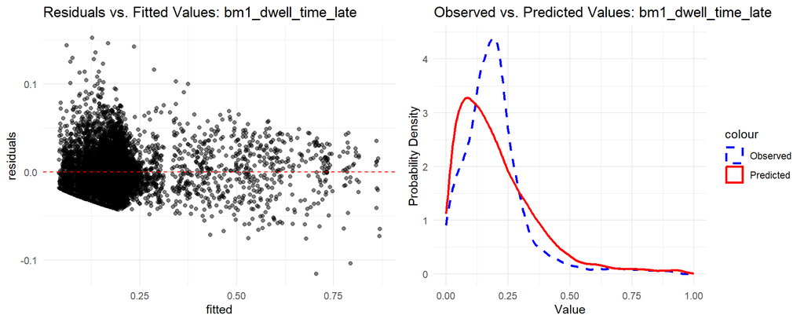

```r
p1 <- diag_resid_fitted(bm1_dwell_time_late)
p2 <- diag_ppc_beta(bm1_dwell_time_late)

grid.arrange(p1, p2, ncol = 2)
```

##### bm2.1_dwell_time_late

**Full Model: Perfectionistic Strivings**

```r
bm2.1_dwell_time_late <- glmmTMB(
  dwell_time_late_t01 ~
    IA_LABEL_f * Perf_Strivings_c +
    block_nr_c +
    Change_category01 +
    #(1 | block_id) +
    (1 + Change_category01 || subject_id),
  dispformula = ~ guessed_block_rule,
  family = beta_family(link = "logit"),
  data = na.omit(sub_et_qu),

)
summary(bm2.1_dwell_time_late)
```

```
##  Family: beta  ( logit )
## Formula:
## dwell_time_late_t01 ~ IA_LABEL_f * Perf_Strivings_c + block_nr_c +
##     Change_category01 + (1 + Change_category01 || subject_id)
## Dispersion:                           ~guessed_block_rule
## Data: na.omit(sub_et_qu)
##
##      AIC      BIC   logLik deviance df.resid
## -18197.3 -18081.8   9114.7 -18229.3    10080
##
## Random effects:
##
## Conditional model:
##  Groups     Name              Variance Std.Dev. Corr
##  subject_id (Intercept)       0.1556   0.3945
##             Change_category01 1.3756   1.1729   0.00
## Number of obs: 10096, groups:  subject_id, 202
##
## Conditional model:
##                                      Estimate Std. Error z value Pr(>|z|)
## (Intercept)                         -1.654178   0.032034  -51.64  < 2e-16 ***
## IA_LABEL_fPositive                   0.044009   0.021481    2.05  0.04048 *
## IA_LABEL_fNegative                   0.065063   0.021324    3.05  0.00228 **
## IA_LABEL_fSuccess                    0.058199   0.021362    2.72  0.00644 **
## IA_LABEL_fFailure                    0.052550   0.021378    2.46  0.01396 *
## Perf_Strivings_c                     0.013311   0.017651    0.75  0.45078
## block_nr_c                          -0.008322   0.002376   -3.50  0.00046 ***
## Change_category01                    0.694330   0.084121    8.25  < 2e-16 ***
## IA_LABEL_fPositive:Perf_Strivings_c -0.025515   0.011879   -2.15  0.03172 *
## IA_LABEL_fNegative:Perf_Strivings_c -0.026025   0.011801   -2.21  0.02743 *
## IA_LABEL_fSuccess:Perf_Strivings_c  -0.001533   0.011859   -0.13  0.89713
## IA_LABEL_fFailure:Perf_Strivings_c  -0.010459   0.011755   -0.89  0.37362
## ---
## Signif. codes:  0 '***' 0.001 '**' 0.01 '*' 0.05 '.' 0.1 ' ' 1
##
## Dispersion model:
##                    Estimate Std. Error z value Pr(>|z|)
## (Intercept)         2.69819    0.03319   81.30  < 2e-16 ***
## guessed_block_rule -0.25959    0.03677   -7.06 1.67e-12 ***
## ---
## Signif. codes:  0 '***' 0.001 '**' 0.01 '*' 0.05 '.' 0.1 ' ' 1
```

**Comparison of model fit (bm2.1 vs. bm1)**

```r
lrtest(bm1_dwell_time_late, bm2.1_dwell_time_late)
```

```
## Likelihood ratio test
##
## Model 1: dwell_time_late_t01 ~ IA_LABEL_f + block_nr_c + Change_category01 +
##     (1 + Change_category01 || subject_id)
## Model 2: dwell_time_late_t01 ~ IA_LABEL_f * Perf_Strivings_c + block_nr_c +
##     Change_category01 + (1 + Change_category01 || subject_id)
##   #Df LogLik Df  Chisq Pr(>Chisq)
## 1  11 9110.1
## 2  16 9114.7  5 9.0759     0.1061
```

```r
AIC(bm1_dwell_time_late, bm2.1_dwell_time_late)
```

```
##                       df       AIC
## bm1_dwell_time_late   11 -18198.26
## bm2.1_dwell_time_late 16 -18197.33
```

##### bm2.2_dwell_time_late

**Full Model: Perfectionistic Concerns**

```r
bm2.2_dwell_time_late <- glmmTMB(
  dwell_time_late_t01 ~
    IA_LABEL_f * Perf_Concerns_c +
    block_nr_c +
    Change_category01 +
    #(1 | block_id) +
    (1 + Change_category01 || subject_id),
  dispformula = ~ guessed_block_rule,
  family = beta_family(link = "logit"),
  data = na.omit(sub_et_qu),

)
summary(bm2.2_dwell_time_late)
```

```
##  Family: beta  ( logit )
## Formula:
## dwell_time_late_t01 ~ IA_LABEL_f * Perf_Concerns_c + block_nr_c +
##     Change_category01 + (1 + Change_category01 || subject_id)
## Dispersion:                           ~guessed_block_rule
## Data: na.omit(sub_et_qu)
##
##      AIC      BIC   logLik deviance df.resid
## -18194.3 -18078.8   9113.2 -18226.3    10080
##
## Random effects:
##
## Conditional model:
##  Groups     Name              Variance Std.Dev. Corr
##  subject_id (Intercept)       0.1537   0.392
##             Change_category01 1.3754   1.173    0.00
## Number of obs: 10096, groups:  subject_id, 202
##
## Conditional model:
##                                     Estimate Std. Error z value Pr(>|z|)
## (Intercept)                        -1.653791   0.031881  -51.87  < 2e-16 ***
## IA_LABEL_fPositive                  0.043319   0.021490    2.02 0.043826 *
## IA_LABEL_fNegative                  0.064481   0.021331    3.02 0.002504 **
## IA_LABEL_fSuccess                   0.057944   0.021368    2.71 0.006693 **
## IA_LABEL_fFailure                   0.052196   0.021384    2.44 0.014648 *
## Perf_Concerns_c                    -0.010997   0.013507   -0.81 0.415541
## block_nr_c                         -0.008340   0.002376   -3.51 0.000448 ***
## Change_category01                   0.694416   0.084116    8.26  < 2e-16 ***
## IA_LABEL_fPositive:Perf_Concerns_c -0.016131   0.009256   -1.74 0.081384 .
## IA_LABEL_fNegative:Perf_Concerns_c -0.012067   0.009188   -1.31 0.189095
## IA_LABEL_fSuccess:Perf_Concerns_c  -0.007904   0.009151   -0.86 0.387712
## IA_LABEL_fFailure:Perf_Concerns_c  -0.005036   0.009104   -0.55 0.580150
## ---
## Signif. codes:  0 '***' 0.001 '**' 0.01 '*' 0.05 '.' 0.1 ' ' 1
##
## Dispersion model:
##                    Estimate Std. Error z value Pr(>|z|)
## (Intercept)         2.69648    0.03316   81.31  < 2e-16 ***
## guessed_block_rule -0.25815    0.03674   -7.03 2.11e-12 ***
## ---
## Signif. codes:  0 '***' 0.001 '**' 0.01 '*' 0.05 '.' 0.1 ' ' 1
```

**Comparison of model fit (bm2.2 vs. bm1)**

```r
lrtest(bm1_dwell_time_late, bm2.2_dwell_time_late)
```

```
## Likelihood ratio test
##
## Model 1: dwell_time_late_t01 ~ IA_LABEL_f + block_nr_c + Change_category01 +
##     (1 + Change_category01 || subject_id)
## Model 2: dwell_time_late_t01 ~ IA_LABEL_f * Perf_Concerns_c + block_nr_c +
##     Change_category01 + (1 + Change_category01 || subject_id)
##   #Df LogLik Df  Chisq Pr(>Chisq)
## 1  11 9110.1
## 2  16 9113.2  5 6.0913     0.2974
```

```r
AIC(bm1_dwell_time_late, bm2.2_dwell_time_late)
```

```
##                       df       AIC
## bm1_dwell_time_late   11 -18198.26
## bm2.2_dwell_time_late 16 -18194.35
```

Neither perfectionism model significantly improved fit over the partial model, so no interactions were decomposed or plotted.

_________________________________________________________________

### Dwell Time (Whole Trial)

Whole-trial dwell time was modeled using a **beta GLMM** with the same logit link used for the phase-specific dwell-time indices. This common link makes the models easier to compare; adequacy for the heavier-tailed whole-trial distribution was checked using the simulation-based diagnostics below.

##### bm0_dwell_time

**Null model**

```r
bm0_dwell_time <- glmmTMB(
  dwell_time_t01 ~
    block_nr_c +
    Change_category01 +
    #(1 | block_id) +
    (1 + Change_category01 || subject_id),
  dispformula = ~ guessed_block_rule,
  family = beta_family(link = "logit"),
  data = na.omit(sub_et_qu),

)
summary(bm0_dwell_time)
```

```
##  Family: beta  ( logit )
## Formula:
## dwell_time_t01 ~ block_nr_c + Change_category01 + (1 + Change_category01 ||
##     subject_id)
## Dispersion:                      ~guessed_block_rule
## Data: na.omit(sub_et_qu)
##
##      AIC      BIC   logLik deviance df.resid
## -29123.0 -29072.5  14568.5 -29137.0    10089
##
## Random effects:
##
## Conditional model:
##  Groups     Name              Variance Std.Dev. Corr
##  subject_id (Intercept)       0.04035  0.2009
##             Change_category01 0.49629  0.7045   0.00
## Number of obs: 10096, groups:  subject_id, 202
##
## Conditional model:
##                     Estimate Std. Error z value Pr(>|z|)
## (Intercept)       -1.5943623  0.0147477 -108.11   <2e-16 ***
## block_nr_c        -0.0009591  0.0012362   -0.78    0.438
## Change_category01  0.8149424  0.0502302   16.22   <2e-16 ***
## ---
## Signif. codes:  0 '***' 0.001 '**' 0.01 '*' 0.05 '.' 0.1 ' ' 1
##
## Dispersion model:
##                    Estimate Std. Error z value Pr(>|z|)
## (Intercept)         4.00616    0.03435  116.61  < 2e-16 ***
## guessed_block_rule -0.13145    0.03834   -3.43 0.000606 ***
## ---
## Signif. codes:  0 '***' 0.001 '**' 0.01 '*' 0.05 '.' 0.1 ' ' 1
```

##### bm1_dwell_time

**Partial Model**

```r
bm1_dwell_time <- glmmTMB(
  dwell_time_t01 ~
    IA_LABEL_f +
    block_nr_c +
    Change_category01 +
    #(1 | block_id) +
    (1 + Change_category01 || subject_id),
  dispformula = ~ guessed_block_rule,
  family = beta_family(link = "logit"),
  data = na.omit(sub_et_qu),

)
summary(bm1_dwell_time)
```

```
##  Family: beta  ( logit )
## Formula:
## dwell_time_t01 ~ IA_LABEL_f + block_nr_c + Change_category01 +
##     (1 + Change_category01 || subject_id)
## Dispersion:                      ~guessed_block_rule
## Data: na.omit(sub_et_qu)
##
##      AIC      BIC   logLik deviance df.resid
## -29149.1 -29069.7  14585.5 -29171.1    10085
##
## Random effects:
##
## Conditional model:
##  Groups     Name              Variance Std.Dev. Corr
##  subject_id (Intercept)       0.04037  0.2009
##             Change_category01 0.49635  0.7045   0.00
## Number of obs: 10096, groups:  subject_id, 202
##
## Conditional model:
##                      Estimate Std. Error z value Pr(>|z|)
## (Intercept)        -1.6301822  0.0163877  -99.48  < 2e-16 ***
## IA_LABEL_fPositive  0.0515285  0.0112159    4.59 4.34e-06 ***
## IA_LABEL_fNegative  0.0471386  0.0111628    4.22 2.41e-05 ***
## IA_LABEL_fSuccess   0.0546116  0.0111633    4.89 9.98e-07 ***
## IA_LABEL_fFailure   0.0249803  0.0112117    2.23   0.0259 *
## block_nr_c         -0.0009706  0.0012342   -0.79   0.4316
## Change_category01   0.8150630  0.0502313   16.23  < 2e-16 ***
## ---
## Signif. codes:  0 '***' 0.001 '**' 0.01 '*' 0.05 '.' 0.1 ' ' 1
##
## Dispersion model:
##                    Estimate Std. Error z value Pr(>|z|)
## (Intercept)         4.01341    0.03438  116.73  < 2e-16 ***
## guessed_block_rule -0.13599    0.03838   -3.54 0.000395 ***
## ---
## Signif. codes:  0 '***' 0.001 '**' 0.01 '*' 0.05 '.' 0.1 ' ' 1
```

**Comparison of model fit (bm1 vs. bm0)**

```r
lrtest(bm1_dwell_time, bm0_dwell_time)
```

```
## Likelihood ratio test
##
## Model 1: dwell_time_t01 ~ IA_LABEL_f + block_nr_c + Change_category01 +
##     (1 + Change_category01 || subject_id)
## Model 2: dwell_time_t01 ~ block_nr_c + Change_category01 + (1 + Change_category01 ||
##     subject_id)
##   #Df LogLik Df  Chisq Pr(>Chisq)
## 1  11  14586
## 2   7  14568 -4 34.085  7.157e-07 ***
## ---
## Signif. codes:  0 '***' 0.001 '**' 0.01 '*' 0.05 '.' 0.1 ' ' 1
```

```r
AIC(bm1_dwell_time, bm0_dwell_time)
```

```
##                df       AIC
## bm1_dwell_time 11 -29149.10
## bm0_dwell_time  7 -29123.01
```

**Model diagnostics (bm1)**

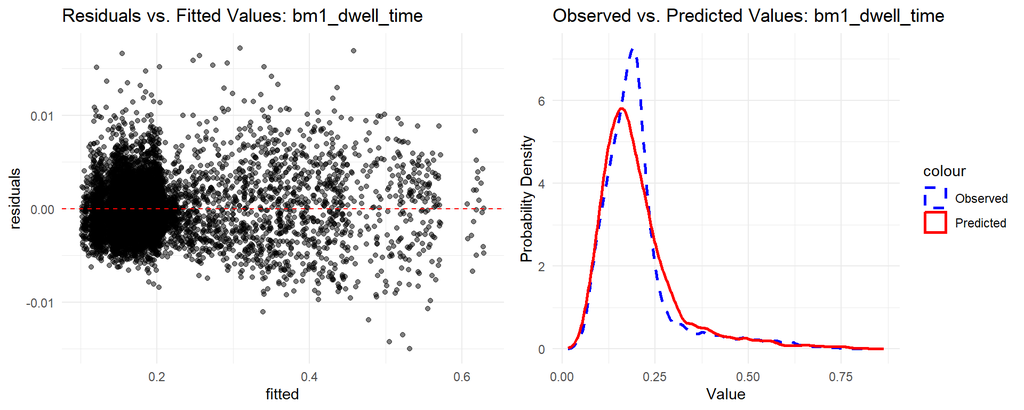

```r
p1 <- diag_resid_fitted(bm1_dwell_time)
p2 <- diag_ppc_beta(bm1_dwell_time)

grid.arrange(p1, p2, ncol = 2)
```

##### bm2.1_dwell_time

**Full Model: Perfectionistic Strivings**

```r
bm2.1_dwell_time <- glmmTMB(
  dwell_time_t01 ~
    IA_LABEL_f * Perf_Strivings_c +
    block_nr_c +
    Change_category01 +
    #(1 | block_id) +
    (1 + Change_category01 || subject_id),
  dispformula = ~ guessed_block_rule,
  family = beta_family(link = "logit"),
  data = na.omit(sub_et_qu),

)
summary(bm2.1_dwell_time)
```

```
##  Family: beta  ( logit )
## Formula:
## dwell_time_t01 ~ IA_LABEL_f * Perf_Strivings_c + block_nr_c +
##     Change_category01 + (1 + Change_category01 || subject_id)
## Dispersion:                      ~guessed_block_rule
## Data: na.omit(sub_et_qu)
##
##      AIC      BIC   logLik deviance df.resid
## -29140.3 -29024.7  14586.1 -29172.3    10080
##
## Random effects:
##
## Conditional model:
##  Groups     Name              Variance Std.Dev. Corr
##  subject_id (Intercept)       0.04028  0.2007
##             Change_category01 0.49633  0.7045   0.00
## Number of obs: 10096, groups:  subject_id, 202
##
## Conditional model:
##                                       Estimate Std. Error z value Pr(>|z|)
## (Intercept)                         -1.6301893  0.0163754  -99.55  < 2e-16 ***
## IA_LABEL_fPositive                   0.0514975  0.0112158    4.59 4.40e-06 ***
## IA_LABEL_fNegative                   0.0471410  0.0111624    4.22 2.41e-05 ***
## IA_LABEL_fSuccess                    0.0546092  0.0111630    4.89 9.98e-07 ***
## IA_LABEL_fFailure                    0.0249798  0.0112114    2.23   0.0259 *
## Perf_Strivings_c                    -0.0036413  0.0090588   -0.40   0.6877
## block_nr_c                          -0.0009712  0.0012342   -0.79   0.4313
## Change_category01                    0.8150871  0.0502299   16.23  < 2e-16 ***
## IA_LABEL_fPositive:Perf_Strivings_c -0.0040535  0.0062037   -0.65   0.5135
## IA_LABEL_fNegative:Perf_Strivings_c  0.0010972  0.0061672    0.18   0.8588
## IA_LABEL_fSuccess:Perf_Strivings_c  -0.0010860  0.0061921   -0.18   0.8608
## IA_LABEL_fFailure:Perf_Strivings_c  -0.0018948  0.0062099   -0.31   0.7603
## ---
## Signif. codes:  0 '***' 0.001 '**' 0.01 '*' 0.05 '.' 0.1 ' ' 1
##
## Dispersion model:
##                    Estimate Std. Error z value Pr(>|z|)
## (Intercept)         4.01302    0.03439  116.68  < 2e-16 ***
## guessed_block_rule -0.13541    0.03839   -3.53  0.00042 ***
## ---
## Signif. codes:  0 '***' 0.001 '**' 0.01 '*' 0.05 '.' 0.1 ' ' 1
```

**Comparison of model fit (bm2.1 vs. bm1)**

```r
lrtest(bm2.1_dwell_time, bm1_dwell_time)
```

```
## Likelihood ratio test
##
## Model 1: dwell_time_t01 ~ IA_LABEL_f * Perf_Strivings_c + block_nr_c +
##     Change_category01 + (1 + Change_category01 || subject_id)
## Model 2: dwell_time_t01 ~ IA_LABEL_f + block_nr_c + Change_category01 +
##     (1 + Change_category01 || subject_id)
##   #Df LogLik Df  Chisq Pr(>Chisq)
## 1  16  14586
## 2  11  14586 -5 1.1608     0.9486
```

```r
AIC(bm2.1_dwell_time, bm1_dwell_time)
```

```
##                  df       AIC
## bm2.1_dwell_time 16 -29140.26
## bm1_dwell_time   11 -29149.10
```

##### bm2.2_dwell_time

**Full Model: Perfectionistic Concerns**

```r
bm2.2_dwell_time <- glmmTMB(
  dwell_time_t01 ~
    IA_LABEL_f * Perf_Concerns_c +
    block_nr_c +
    Change_category01 +
    #(1 | block_id) +
    (1 + Change_category01 || subject_id),
  dispformula = ~ guessed_block_rule,
  family = beta_family(link = "logit"),
  data = na.omit(sub_et_qu),

)
summary(bm2.2_dwell_time)
```

```
##  Family: beta  ( logit )
## Formula:          dwell_time_t01 ~ IA_LABEL_f * Perf_Concerns_c + block_nr_c +
##     Change_category01 + (1 + Change_category01 || subject_id)
## Dispersion:                      ~guessed_block_rule
## Data: na.omit(sub_et_qu)
##
##      AIC      BIC   logLik deviance df.resid
## -29143.1 -29027.6  14587.5 -29175.1    10080
##
## Random effects:
##
## Conditional model:
##  Groups     Name              Variance Std.Dev. Corr
##  subject_id (Intercept)       0.04028  0.2007
##             Change_category01 0.49638  0.7045   0.00
## Number of obs: 10096, groups:  subject_id, 202
##
## Conditional model:
##                                      Estimate Std. Error z value Pr(>|z|)
## (Intercept)                        -1.6302202  0.0163738  -99.56  < 2e-16 ***
## IA_LABEL_fPositive                  0.0514546  0.0112146    4.59 4.47e-06 ***
## IA_LABEL_fNegative                  0.0471108  0.0111611    4.22 2.43e-05 ***
## IA_LABEL_fSuccess                   0.0545788  0.0111616    4.89 1.01e-06 ***
## IA_LABEL_fFailure                   0.0249592  0.0112100    2.23    0.026 *
## Perf_Concerns_c                    -0.0042131  0.0069668   -0.60    0.545
## block_nr_c                         -0.0009739  0.0012340   -0.79    0.430
## Change_category01                   0.8151460  0.0502325   16.23  < 2e-16 ***
## IA_LABEL_fPositive:Perf_Concerns_c -0.0038000  0.0047975   -0.79    0.428
## IA_LABEL_fNegative:Perf_Concerns_c  0.0039100  0.0047671    0.82    0.412
## IA_LABEL_fSuccess:Perf_Concerns_c  -0.0022045  0.0047777   -0.46    0.645
## IA_LABEL_fFailure:Perf_Concerns_c   0.0023002  0.0047988    0.48    0.632
## ---
## Signif. codes:  0 '***' 0.001 '**' 0.01 '*' 0.05 '.' 0.1 ' ' 1
##
## Dispersion model:
##                    Estimate Std. Error z value Pr(>|z|)
## (Intercept)         4.01299    0.03439  116.70  < 2e-16 ***
## guessed_block_rule -0.13499    0.03838   -3.52 0.000436 ***
## ---
## Signif. codes:  0 '***' 0.001 '**' 0.01 '*' 0.05 '.' 0.1 ' ' 1
```

**Comparison of model fit (bm2.2 vs. bm1)**

```r
lrtest(bm2.2_dwell_time, bm1_dwell_time)
```

```
## Likelihood ratio test
##
## Model 1: dwell_time_t01 ~ IA_LABEL_f * Perf_Concerns_c + block_nr_c +
##     Change_category01 + (1 + Change_category01 || subject_id)
## Model 2: dwell_time_t01 ~ IA_LABEL_f + block_nr_c + Change_category01 +
##     (1 + Change_category01 || subject_id)
##   #Df LogLik Df  Chisq Pr(>Chisq)
## 1  16  14588
## 2  11  14586 -5 3.9778     0.5526
```

```r
AIC(bm2.2_dwell_time, bm1_dwell_time)
```

```
##                  df       AIC
## bm2.2_dwell_time 16 -29143.08
## bm1_dwell_time   11 -29149.10
```

Neither perfectionism model significantly improved fit over the partial model, so no interactions were decomposed or plotted.

_________________________________________________________________

## iii) Gamma Regression for Response Time

Response time was analyzed using **gamma generalized linear mixed-effects regression**, as this variable was continuous, strictly positive, and right-skewed.

The gamma distribution is well suited for such data because it accommodates positive values with asymmetric, long-tailed distributions. A **log link** was used so that predicted values remained positive and coefficients could be interpreted on a multiplicative scale.

In addition to modeling the expected value of the outcome ($\mu$), `glmmTMB` allows the **gamma dispersion parameter** to be modeled as a function of predictors. Rule awareness was included in this submodel to allow residual variability in response time to differ after participants inferred the block rule.

### Model Overview

- **Outcome:** Response time
- **Distribution:** Gamma
- **Link function:** Log
- **Parameters:**
  - $\mu$: mean (expected response time)
  - $\sigma$: dispersion (variability in response time)

Exponentiating a gamma-model coefficient does not yield an additive change in milliseconds. (The resulting value is a conditional multiplicative ratio in expected response time: for example, 1.10 indicates a 10% increase and 0.90 a 10% decrease for a one-unit predictor change, holding the other terms constant.) Response-scale interpretation uses estimated marginal trends or exponentiated predictions formed from the complete linear predictor.

### Model Specification for Response Times

#### Mean Submodel ($\mu$)

$$\begin{aligned}
\log(\mu_{ij}) ={}& \beta_0 + \sum_{k=1}^{4}\beta_k C_{k,ij} +
\beta_5 Perf_j + \beta_6 TrialOrder_{ij} \\
&+ \sum_{k=1}^{4}\gamma_k(C_{k,ij}\times Perf_j) \\
&+ u_{0j}.
\end{aligned}$$

where:

- $\mu_{ij}$: expected response time for trial $i$ and participant $j$
- $C_{k,ij}$: four indicator variables for positive, negative, success-related, and failure-related changed words; neutral is the reference category
- $Perf_j$: perfectionism (Perfectionistic Strivings or Perfectionistic Concerns, modeled in separate analyses; mean-centered)
- $TrialOrder_{ij}$: numeric presentation order of the trial (1–75)
- $u_{0j}$: participant-specific random intercept

#### Dispersion Submodel ($\sigma$)

$$\log(\sigma_{ij}) = \gamma_0 + \gamma_1 BR_{ij}$$

where:

- $\sigma_{ij}$: dispersion (variability in response time)
- $BR_{ij}$: rule awareness (0 = no, 1 = yes)

### Data Preparation for Gamma Models

To reduce memory usage and computation time, a subset containing only variables required for model fitting was created.

```r
sub_rt_qu <- rt_qu[c("response_time",
                     "subject_id", "block_id", "trial_nr_c", "guessed_block_rule",
                     "Change_category_f", "Perf_Strivings_c",
                     "Perf_Concerns_c")]
```

### 4. Response Time

Response time was modeled using a gamma GLMM with a log link for the mean parameter.

##### gm0_response_time

**Null model**

```r
gm0_response_time <- glmmTMB(
  response_time ~
    trial_nr_c +
    #(1 | block_id) +
    (1 | subject_id),
  family = Gamma(link = "log"),
  dispformula = ~ guessed_block_rule,
  data = na.omit(sub_rt_qu),

)
summary(gm0_response_time)
```

```
##  Family: Gamma  ( log )
## Formula:          response_time ~ trial_nr_c + (1 | subject_id)
## Dispersion:                     ~guessed_block_rule
## Data: na.omit(sub_rt_qu)
##
##       AIC       BIC    logLik  deviance  df.resid
##  238360.4  238398.5 -119175.2  238350.4     14900
##
## Random effects:
##
## Conditional model:
##  Groups     Name        Variance Std.Dev.
##  subject_id (Intercept) 0.08151  0.2855
## Number of obs: 14905, groups:  subject_id, 202
##
## Conditional model:
##               Estimate Std. Error z value Pr(>|z|)
## (Intercept)  7.3958518  0.0204470   361.7   <2e-16 ***
## trial_nr_c  -0.0050426  0.0001759   -28.7   <2e-16 ***
## ---
## Signif. codes:  0 '***' 0.001 '**' 0.01 '*' 0.05 '.' 0.1 ' ' 1
##
## Dispersion model:
##                    Estimate Std. Error z value Pr(>|z|)
## (Intercept)         1.56013    0.02678   58.25   <2e-16 ***
## guessed_block_rule -0.03682    0.02970   -1.24    0.215
## ---
## Signif. codes:  0 '***' 0.001 '**' 0.01 '*' 0.05 '.' 0.1 ' ' 1
```

##### gm1_response_time

**Partial Model**

```r
gm1_response_time <- glmmTMB(
  response_time ~
    Change_category_f +
    trial_nr_c +
    #(1 | block_id) +
    (1 | subject_id),
  family = Gamma(link = "log"),
  dispformula = ~ guessed_block_rule,
  data = na.omit(sub_rt_qu),

)
summary(gm1_response_time)
```

```
##  Family: Gamma  ( log )
## Formula:
## response_time ~ Change_category_f + trial_nr_c + (1 | subject_id)
## Dispersion:                     ~guessed_block_rule
## Data: na.omit(sub_rt_qu)
##
##       AIC       BIC    logLik  deviance  df.resid
##  238319.1  238387.6 -119150.5  238301.1     14896
##
## Random effects:
##
## Conditional model:
##  Groups     Name        Variance Std.Dev.
##  subject_id (Intercept) 0.08173  0.2859
## Number of obs: 14905, groups:  subject_id, 202
##
## Conditional model:
##                             Estimate Std. Error z value Pr(>|z|)
## (Intercept)                7.4384023  0.0218543   340.4  < 2e-16 ***
## Change_category_fPositive -0.0387192  0.0120853    -3.2 0.001356 **
## Change_category_fNegative -0.0443540  0.0120893    -3.7 0.000244 ***
## Change_category_fSuccess  -0.0467923  0.0120763    -3.9 0.000107 ***
## Change_category_fFailure  -0.0844317  0.0120719    -7.0 2.67e-12 ***
## trial_nr_c                -0.0050679  0.0001761   -28.8  < 2e-16 ***
## ---
## Signif. codes:  0 '***' 0.001 '**' 0.01 '*' 0.05 '.' 0.1 ' ' 1
##
## Dispersion model:
##                    Estimate Std. Error z value Pr(>|z|)
## (Intercept)         1.56605    0.02680   58.44   <2e-16 ***
## guessed_block_rule -0.04020    0.02971   -1.35    0.176
## ---
## Signif. codes:  0 '***' 0.001 '**' 0.01 '*' 0.05 '.' 0.1 ' ' 1
```

**Comparison of model fit (gm1 vs. gm0)**

```r
lrtest(gm1_response_time, gm0_response_time)
```

```
## Likelihood ratio test
##
## Model 1: response_time ~ Change_category_f + trial_nr_c + (1 | subject_id)
## Model 2: response_time ~ trial_nr_c + (1 | subject_id)
##   #Df  LogLik Df  Chisq Pr(>Chisq)
## 1   9 -119151
## 2   5 -119175 -4 49.354  4.925e-10 ***
## ---
## Signif. codes:  0 '***' 0.001 '**' 0.01 '*' 0.05 '.' 0.1 ' ' 1
```

```r
AIC(gm1_response_time, gm0_response_time)
```

```
##                   df      AIC
## gm1_response_time  9 238319.1
## gm0_response_time  5 238360.4
```

**Model diagnostics (gm1)**

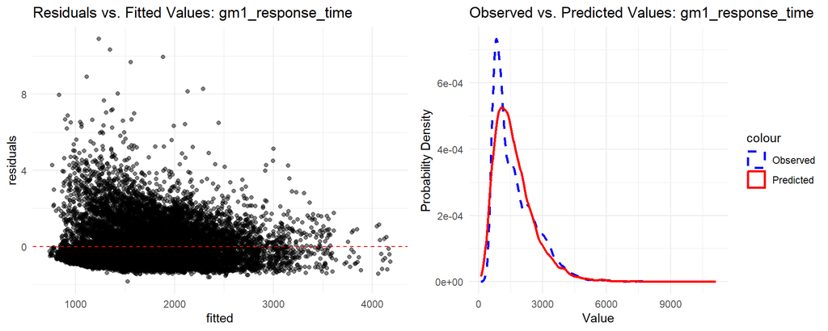

```r
p1 <- diag_resid_fitted(gm1_response_time)
p2 <- diag_ppc_gamma(gm1_response_time)

grid.arrange(p1, p2, ncol = 2)
```

##### gm2.1_response_time

**Full Model: Perfectionistic Strivings**

```r
gm2.1_response_time <- glmmTMB(
  response_time ~
    Change_category_f * Perf_Strivings_c +
    trial_nr_c +
    #(1 | block_id) +
    (1 | subject_id),
  family = Gamma(link = "log"),
  dispformula = ~ guessed_block_rule,
  data = na.omit(sub_rt_qu),

)
summary(gm2.1_response_time)
```

```
##  Family: Gamma  ( log )
## Formula:
## response_time ~ Change_category_f * Perf_Strivings_c + trial_nr_c +
##     (1 | subject_id)
## Dispersion:                     ~guessed_block_rule
## Data: na.omit(sub_rt_qu)
##
##       AIC       BIC    logLik  deviance  df.resid
##  238326.0  238432.5 -119149.0  238298.0     14891
##
## Random effects:
##
## Conditional model:
##  Groups     Name        Variance Std.Dev.
##  subject_id (Intercept) 0.08171  0.2858
## Number of obs: 14905, groups:  subject_id, 202
##
## Conditional model:
##                                              Estimate Std. Error z value
## (Intercept)                                 7.4384029  0.0218516   340.4
## Change_category_fPositive                  -0.0387133  0.0120843    -3.2
## Change_category_fNegative                  -0.0443717  0.0120881    -3.7
## Change_category_fSuccess                   -0.0467873  0.0120750    -3.9
## Change_category_fFailure                   -0.0845111  0.0120707    -7.0
## Perf_Strivings_c                           -0.0007087  0.0120994    -0.1
## trial_nr_c                                 -0.0050727  0.0001763   -28.8
## Change_category_fPositive:Perf_Strivings_c  0.0009312  0.0066977     0.1
## Change_category_fNegative:Perf_Strivings_c -0.0022999  0.0066667    -0.3
## Change_category_fSuccess:Perf_Strivings_c  -0.0043211  0.0066918    -0.6
## Change_category_fFailure:Perf_Strivings_c   0.0066098  0.0066931     1.0
##                                            Pr(>|z|)
## (Intercept)                                 < 2e-16 ***
## Change_category_fPositive                  0.001357 **
## Change_category_fNegative                  0.000242 ***
## Change_category_fSuccess                   0.000107 ***
## Change_category_fFailure                   2.53e-12 ***
## Perf_Strivings_c                           0.953293
## trial_nr_c                                  < 2e-16 ***
## Change_category_fPositive:Perf_Strivings_c 0.889426
## Change_category_fNegative:Perf_Strivings_c 0.730109
## Change_category_fSuccess:Perf_Strivings_c  0.518451
## Change_category_fFailure:Perf_Strivings_c  0.323366
## ---
## Signif. codes:  0 '***' 0.001 '**' 0.01 '*' 0.05 '.' 0.1 ' ' 1
##
## Dispersion model:
##                    Estimate Std. Error z value Pr(>|z|)
## (Intercept)         1.56719    0.02681   58.46   <2e-16 ***
## guessed_block_rule -0.04135    0.02972   -1.39    0.164
## ---
## Signif. codes:  0 '***' 0.001 '**' 0.01 '*' 0.05 '.' 0.1 ' ' 1
```

**Comparison of model fit (gm2.1 vs. gm1)**

```r
lrtest(gm2.1_response_time, gm1_response_time)
```

```
## Likelihood ratio test
##
## Model 1: response_time ~ Change_category_f * Perf_Strivings_c + trial_nr_c +
##     (1 | subject_id)
## Model 2: response_time ~ Change_category_f + trial_nr_c + (1 | subject_id)
##   #Df  LogLik Df  Chisq Pr(>Chisq)
## 1  14 -119149
## 2   9 -119151 -5 3.0623     0.6904
```

```r
AIC(gm2.1_response_time, gm1_response_time)
```

```
##                     df      AIC
## gm2.1_response_time 14 238326.0
## gm1_response_time    9 238319.1
```

##### gm2.2_response_time

**Full Model: Perfectionistic Concerns**

```r
gm2.2_response_time <- glmmTMB(
  response_time ~
    Change_category_f * Perf_Concerns_c +
    trial_nr_c +
    #(1 | block_id) +
    (1 | subject_id),
  family = Gamma(link = "log"),
  dispformula = ~ guessed_block_rule,
  data = na.omit(sub_rt_qu),

)
summary(gm2.2_response_time)
```

```
##  Family: Gamma  ( log )
## Formula:
## response_time ~ Change_category_f * Perf_Concerns_c + trial_nr_c +
##     (1 | subject_id)
## Dispersion:                     ~guessed_block_rule
## Data: na.omit(sub_rt_qu)
##
##       AIC       BIC    logLik  deviance  df.resid
##  238321.1  238427.6 -119146.6  238293.1     14891
##
## Random effects:
##
## Conditional model:
##  Groups     Name        Variance Std.Dev.
##  subject_id (Intercept) 0.08149  0.2855
## Number of obs: 14905, groups:  subject_id, 202
##
## Conditional model:
##                                             Estimate Std. Error z value
## (Intercept)                                7.4382291  0.0218272   340.8
## Change_category_fPositive                 -0.0385351  0.0120828    -3.2
## Change_category_fNegative                 -0.0441807  0.0120862    -3.7
## Change_category_fSuccess                  -0.0466534  0.0120730    -3.9
## Change_category_fFailure                  -0.0843234  0.0120686    -7.0
## Perf_Concerns_c                            0.0154059  0.0092967     1.7
## trial_nr_c                                -0.0050781  0.0001762   -28.8
## Change_category_fPositive:Perf_Concerns_c -0.0066267  0.0051720    -1.3
## Change_category_fNegative:Perf_Concerns_c -0.0110823  0.0051789    -2.1
## Change_category_fSuccess:Perf_Concerns_c  -0.0112670  0.0051532    -2.2
## Change_category_fFailure:Perf_Concerns_c  -0.0113487  0.0051470    -2.2
##                                           Pr(>|z|)
## (Intercept)                                < 2e-16 ***
## Change_category_fPositive                 0.001426 **
## Change_category_fNegative                 0.000257 ***
## Change_category_fSuccess                  0.000111 ***
## Change_category_fFailure                  2.81e-12 ***
## Perf_Concerns_c                           0.097490 .
## trial_nr_c                                 < 2e-16 ***
## Change_category_fPositive:Perf_Concerns_c 0.200105
## Change_category_fNegative:Perf_Concerns_c 0.032362 *
## Change_category_fSuccess:Perf_Concerns_c  0.028787 *
## Change_category_fFailure:Perf_Concerns_c  0.027460 *
## ---
## Signif. codes:  0 '***' 0.001 '**' 0.01 '*' 0.05 '.' 0.1 ' ' 1
##
## Dispersion model:
##                    Estimate Std. Error z value Pr(>|z|)
## (Intercept)         1.56587    0.02681   58.40   <2e-16 ***
## guessed_block_rule -0.03940    0.02973   -1.33    0.185
## ---
## Signif. codes:  0 '***' 0.001 '**' 0.01 '*' 0.05 '.' 0.1 ' ' 1
```

**Comparison of model fit (gm2.2 vs. gm1)**

```r
lrtest(gm2.2_response_time, gm1_response_time)
```

```
## Likelihood ratio test
##
## Model 1: response_time ~ Change_category_f * Perf_Concerns_c + trial_nr_c +
##     (1 | subject_id)
## Model 2: response_time ~ Change_category_f + trial_nr_c + (1 | subject_id)
##   #Df  LogLik Df  Chisq Pr(>Chisq)
## 1  14 -119147
## 2   9 -119151 -5 7.9723     0.1578
```

```r
AIC(gm2.2_response_time, gm1_response_time)
```

```
##                     df      AIC
## gm2.2_response_time 14 238321.1
## gm1_response_time    9 238319.1
```

Neither perfectionism model significantly improved fit over the partial model, so no interactions were decomposed or plotted.

_________________________________________________________________

# References

Barr, D. J., Levy, R., Scheepers, C., & Tily, H. J. (2013). Random effects structure for confirmatory hypothesis testing: Keep it maximal. Journal of Memory and Language, 68(3), 255–278. https://doi.org/10.1016/j.jml.2012.11.001

Bolker, B. M., Brooks, M. E., Clark, C. J., Geange, S. W., Poulsen, J. R., Stevens, M. H. H., & White, J.-S. S. (2009). Generalized linear mixed models: A practical guide for ecology and evolution. Trends in Ecology & Evolution, 24(3), 127–135. https://doi.org/10.1016/j.tree.2008.10.008

Douma, J. C., & Weedon, J. T. (2019). Analysing continuous proportions in ecology and evolution: A practical introduction to beta and Dirichlet regression. Methods in Ecology and Evolution, 10(9), 1412–1430. https://doi.org/10.1111/2041-210X.13234

Lo, S., & Andrews, S. (2015). To transform or not to transform: Using generalized linear mixed models to analyse reaction time data. Frontiers in Psychology, 6, Article 1171. https://doi.org/10.3389/fpsyg.2015.01171

Skinner, I. W., Hübscher, M., Moseley, G. L., Lee, H., Wand, B. M., Traeger, A. C., Gustin, S. M., & McAuley, J. H. (2018). The reliability of eyetracking to assess attentional bias to threatening words in healthy individuals. Behavior Research Methods, 50(5), 1778–1792. https://doi.org/10.3758/s13428-017-0946-y

Stoeber, J., & Otto, K. (2006). Positive Conceptions of Perfectionism: Approaches, Evidence, Challenges. Personality and Social Psychology Review, 10(4), 295–319. https://doi.org/10.1207/s15327957pspr1004_2

Brooks, M. E., Kristensen, K., van Benthem, K. J., Magnusson, A., Berg, C. W., Nielsen, A., Skaug, H. J., Mächler, M., & Bolker, B. M. (2017). glmmTMB balances speed and flexibility among packages for zero-inflated generalized linear mixed modeling. *The R Journal, 9*(2), 378–400. https://doi.org/10.32614/RJ-2017-066